# Selective stop signal task and antisocial phenotypes

Drew E. Winters, PhD.

05 December, 2024

# 1 Setup

## 1.1 Packages

```r
library(ggplot2)
library(psych)
library(car)
```

## 1.2 Loading data

```r
# full data
dat_sssst <- read.csv(dataframe_sssst_final_subs)
# data to report based on sst guidelines
  ## see: https://doi.org/10.7554/eLife.46323
dat_report <- read.csv(dataframe_sst_reporting)
  ## removing participants
dat_report <- dat_report[-which(dat_report$remove==1),]
```

### 1.2.1 interactions

```r
dat_sssst$int_cutest <- resid(
  lm(I(dat_sssst$group_di * dat_sssst$cu_total_mean) ~ dat_sssst$group_di + dat_sssst$cu_total_mean)
)
dat_sssst$int_cdtest <- resid(
  lm(I(dat_sssst$group_di * dat_sssst$sdq_cd) ~ dat_sssst$group_di + dat_sssst$sdq_cd)
)
dat_sssst$int_cucd <- resid(
  lm(I(dat_sssst$sdq_cd * dat_sssst$cu_total_mean) ~ dat_sssst$sdq_cd + dat_sssst$cu_total_mean)
)
dat_sssst$int_cucdtest <- resid(
  lm(
    I(dat_sssst$sdq_cd * dat_sssst$cu_total_mean * dat_sssst$group_di) ~
      dat_sssst$sdq_cd + dat_sssst$cu_total_mean + dat_sssst$group_di)
)
```

### 1.2.2 Recoding variables

#### 1.2.2.1 Passive Control reaction time

##### 1.2.2.1.1 Reverse coding & reasoning

- For passive Control reaction time
  - longer times = better Control
  - shorter time = worse Control
- This is the opposite of the selective Control and go trials
  - longer times = worse selective Control or go reaction
  - shorter times = better selective Control or go reaction
- therefore - to have commensurate comparisons we reverse code by the following:
  - max rt (1.5) - rt (individual rt)
- This results in a metric that is in the same direction as the others for interpretation as follows:
  - longer times = worse passive Control
  - shorter times = better passive Control
- we will use this metric for analysis of passive Control trials

```r
dat_sssst$ssst_mean_rt_ignore_rc <- (1.5-dat_sssst$ssst_mean_rt_ignore)
```

- Additionally, we need to include the recording into the total reaction time
  - This better reflects the same direction of our reaction times
  - will be used in total reaction time analyses

```r
dat_sssst$ssst_mean_rt_rc <- (
  (
    dat_sssst$ssst_mean_rt_go +
      dat_sssst$ssst_mean_rt_ignore_rc +
      dat_sssst$ssst_mean_rt_stop
    )/3
  )
```

### 1.2.3 subset of data with test only

```r
gp_ind <- which(dat_sssst$group_di == 1)

dat_test <- dat_sssst[gp_ind, ]
```

# 2 Assumption testing

## 2.1 Dataframe for assumption testing

## 2.2 Additivity - Multicollinerity

```
##                   s__ sdq_c c_ sx_ i cr sdq_h sdq_n
## ssst_mean_rt      1
## sdq_cd                1
## cu_total_mean         .     1
## sex_male                       1
## iq                                 1
## careless                             1
## sdq_hyperactivity     ,     .           1
## sdq_internalizing     .     .  .        .     1
## attr(,"legend")
## [1] 0 ' ' 0.3 '.' 0.6 ',' 0.8 '+' 0.9 '*' 0.95 'B' 1
```

> THere are no ‘+’, ’*‘, or ’B’ suggesting a high correlatoni betwen variables so these are fine.

## 2.3 Normality of residuals

```r
set.seed(1982)
random <- rchisq(nrow(dat_test1[,-c(1)]), 10)
  # creating a fake regression
    # remove the ID variable since you are regression the entire data set
fake <- lm(random~.,data=dat_test1[,-c(1)])
  # creating studentized residuals
studentized <- rstudent(fake)
```

### 2.3.1 Distribution of studentized residuals

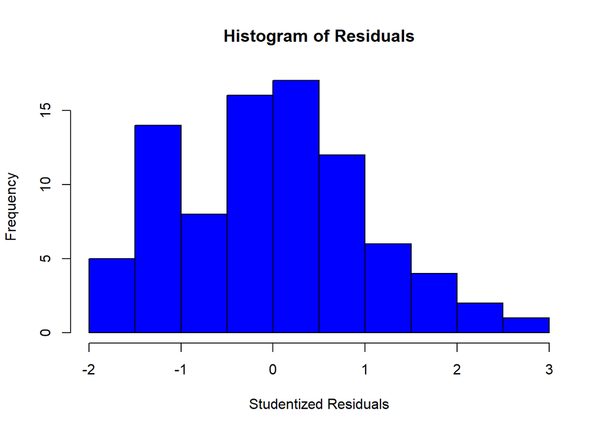

> Evenly distributed visually – let’s check skewnes and kurtosis

```r
psych::describe(studentized)
```

|  | vars | n | mean | sd | median | trimmed | mad | min | max | range | skew | kurtosis | se |
| --- | --- | --- | --- | --- | --- | --- | --- | --- | --- | --- | --- | --- | --- |
| X1 | 1 | 85 | 0.003915043 | 1.011859 | -0.001119104 | -0.03800998 | 1.098786 | -1.766465 | 2.543938 | 4.310403 | 0.2724251 | -0.7057353 | 0.1097515 |

> Not kurtotic or skewed – lets get a more accurate estimate of the mean of residuals to make sure its close to 0

```
## [1] 1.675029e-17
```

> Mean is very close to 0 (mean < 0.0001)

### 2.3.2 Linearity of residuals

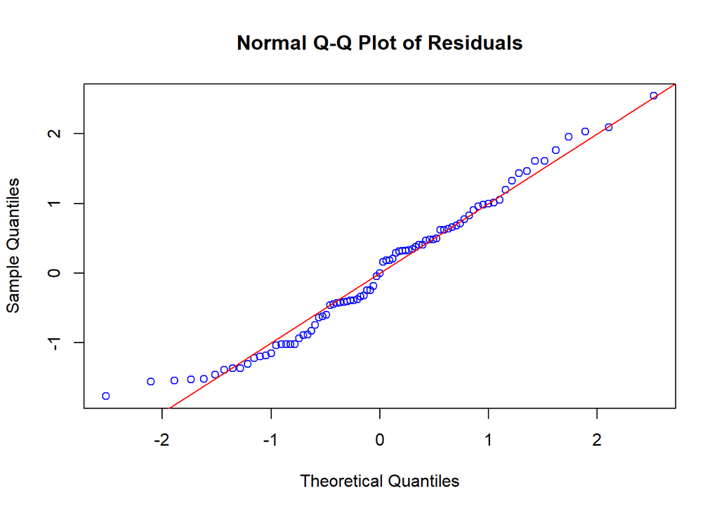

> The majority of the data is on the line

### 2.3.3 Fitted residual normality

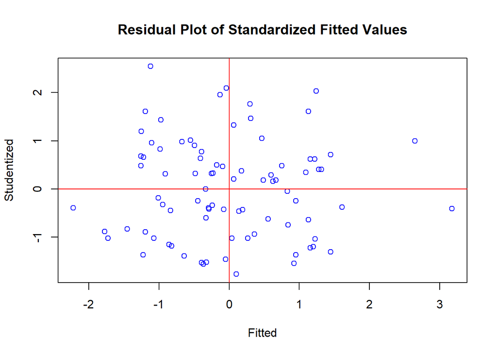

> data look evenly dispursed across the figure in each sector

### 2.3.4 Autocorrelation

```
##  lag Autocorrelation D-W Statistic p-value
##    1     -0.07919495      2.147934   0.458
##  Alternative hypothesis: rho != 0
```

> test is not statistically significant (p>.05) and the statistic is close to 2

## 2.4 Multicollinearity of predictors and controls

| Variables | Tolerance | VIF |
| --- | --- | --- |
| ssst_mean_rt | 0.8439545 | 1.184898 |
| sdq_cd | 0.4938098 | 2.025071 |
| cu_total_mean | 0.5857929 | 1.707088 |
| sex_male | 0.8017316 | 1.247300 |
| iq | 0.8819863 | 1.133804 |
| careless | 0.9723369 | 1.028450 |
| sdq_hyperactivity | 0.4484661 | 2.229823 |
| sdq_internalizing | 0.5688860 | 1.757822 |

> after including all variables that will be used as controls and predictors a only a small portion of each variable is filtered away meaning we do not have multicollinearity assumption met as evidence by all VIF < 2.5 all tolerance is > or ~ 0.5

# 3 Descripive information

## 3.1 SST necessary reporting

- Must report - see: https://doi.org/10.7554/eLife.46323
  - Go trials: Probability of omissions
  - Go trials: Probability of choice errors
  - Go trials: RT mean and variance (by group)
  - Control (passive and selective): Probability of response
  - Control (passive and selective): RT mean and variance (by group)
  - Stop signal delay: mean and variance

### 3.1.1 All participants

```r
as.data.frame(describe(dat_report))[4:11,c(3:5,7:10)]
```

|  | mean | sd | median | mad | min | max | range |
| --- | --- | --- | --- | --- | --- | --- | --- |
| pb_go_omission | 0.15443196 | 0.18473042 | 0.07407407 | 0.1098222 | 0.00000000 | 0.7740741 | 0.7740741 |
| pb_go_choice_err | 0.01964211 | 0.06422144 | 0.00000000 | 0.0000000 | 0.00000000 | 0.4851852 | 0.4851852 |
| pb_ignore_respond | 0.83108614 | 0.19570429 | 0.92222222 | 0.1153133 | 0.24444444 | 1.0000000 | 0.7555556 |
| pb_stop_respond | 0.71573034 | 0.29360854 | 0.83333333 | 0.2471000 | 0.06666667 | 1.0000000 | 0.9333333 |
| ssd_average | 0.72735705 | 0.25513780 | 0.71366667 | 0.3630723 | 0.12266667 | 0.9604444 | 0.8377778 |
| rt_mean_go | 0.68643689 | 0.34500931 | 0.64432296 | 0.4486578 | 0.12021889 | 1.3564622 | 1.2362433 |
| rt_mean_ignore | 0.75604921 | 0.40370551 | 0.64607556 | 0.5078531 | 0.12220778 | 1.4595433 | 1.3373356 |
| rt_mean_stop | 0.70744261 | 0.36017525 | 0.65054889 | 0.4700748 | 0.14309667 | 1.3749511 | 1.2318544 |

### 3.1.2 by group

#### 3.1.2.1 Treatment

```r
as.data.frame(describe(dat_report[which(dat_report$group_di==1),]))[4:11,c(3:5,7:10)]
```

|  | mean | sd | median | mad | min | max | range |
| --- | --- | --- | --- | --- | --- | --- | --- |
| pb_go_omission | 0.26787604 | 0.18117319 | 0.244444444 | 0.159242222 | 0.003703704 | 0.7740741 | 0.7703704 |
| pb_go_choice_err | 0.03567649 | 0.08353095 | 0.003703704 | 0.005491111 | 0.000000000 | 0.4851852 | 0.4851852 |
| pb_ignore_respond | 0.70770975 | 0.18709942 | 0.755555556 | 0.164733333 | 0.244444444 | 1.0000000 | 0.7555556 |
| pb_stop_respond | 0.49591837 | 0.21889516 | 0.444444444 | 0.197680000 | 0.066666667 | 0.9888889 | 0.9222222 |
| ssd_average | 0.53892517 | 0.19667911 | 0.623222222 | 0.129645133 | 0.122666667 | 0.9596667 | 0.8370000 |
| rt_mean_go | 0.94845656 | 0.23828096 | 0.978061481 | 0.200972470 | 0.313225926 | 1.3564622 | 1.0432363 |
| rt_mean_ignore | 1.07230846 | 0.25792176 | 1.137482222 | 0.190219227 | 0.325891111 | 1.4595433 | 1.1336522 |
| rt_mean_stop | 0.98386073 | 0.24292341 | 1.040622222 | 0.212886534 | 0.317900000 | 1.3749511 | 1.0570511 |

#### 3.1.2.2 Control

```r
as.data.frame(describe(dat_report[which(dat_report$group_di==0),]))[4:11,c(3:5,7:10)]
```

|  | mean | sd | median | mad | min | max | range |
| --- | --- | --- | --- | --- | --- | --- | --- |
| pb_go_omission | 0.01546296 | 0.025005891 | 0.003703704 | 0.0054911111 | 0.0000000 | 0.1296296 | 0.12962963 |
| pb_go_choice_err | 0.00000000 | 0.000000000 | 0.000000000 | 0.0000000000 | 0.0000000 | 0.0000000 | 0.00000000 |
| pb_ignore_respond | 0.98222222 | 0.027996292 | 0.988888889 | 0.0164733333 | 0.8666667 | 1.0000000 | 0.13333333 |
| pb_stop_respond | 0.98500000 | 0.021725211 | 0.994444444 | 0.0082366667 | 0.9222222 | 1.0000000 | 0.07777778 |
| ssd_average | 0.95818611 | 0.003628384 | 0.959000000 | 0.0006589333 | 0.9376667 | 0.9604444 | 0.02277778 |
| rt_mean_go | 0.36546279 | 0.082336737 | 0.355691111 | 0.0739946441 | 0.1202189 | 0.5859959 | 0.46577704 |
| rt_mean_ignore | 0.36863164 | 0.079141409 | 0.357793333 | 0.0670711767 | 0.1222078 | 0.5780911 | 0.45588333 |
| rt_mean_stop | 0.36883042 | 0.080554268 | 0.358820000 | 0.0689285450 | 0.1430967 | 0.5846133 | 0.44151667 |

### 3.1.3 Between group differences

```r
t_test_results <- apply(dat_report[, -c(1:3)], 2, function(x) {
  t.test(x ~ dat_report$group_di)$p.value
})

as.data.frame(t_test_results)
```

|  | t_test_results |
| --- | --- |
| pb_go_omission | 5.173393e-13 |
| pb_go_choice_err | 4.394194e-03 |
| pb_ignore_respond | 8.950224e-14 |
| pb_stop_respond | 1.304927e-20 |
| ssd_average | 1.165866e-19 |
| rt_mean_go | 1.392407e-23 |
| rt_mean_ignore | 1.101466e-25 |
| rt_mean_stop | 3.059607e-24 |

## 3.2 Descriptive statistics

- see descriptive statistics from dual-task analysis
  - same data frame
  - same participants

## 3.3 Power analysis

### 3.3.1 Beta within group for 90% power

#### 3.3.1.1 Test group

```r
test_r <- pwr::pwr.r.test(36,NULL, 0.05, 0.90)$r
cat("Beta for 90% power in TEST group = ", test_r_x_beta <- test_r*(var(dat_sssst$ssst_mean_rt)/var(dat_sssst$cu_total_sum)))
```

```
## Beta for 90% power in TEST group =  0.001357254
```

#### 3.3.1.2 Control group

```r
ctrl_r <- pwr::pwr.r.test(49,NULL, 0.05, 0.90)$r
cat("Beta for 90% power in CONTROL group = ",ctrl_r_x_beta <- ctrl_r*(var(dat_sssst$ssst_mean_rt)/var(dat_sssst$cu_total_sum)))
```

```
## Beta for 90% power in CONTROL group =  0.001182845
```

# 4 Primary Analyses

## 4.1 Test subjects only

### 4.1.1 SSRT ~

#### 4.1.1.1 Model

```r
m1 <- lm(ssrt ~
           sdq_cd +
           cu_total_mean +
           int_cucd +
           sex_male +
           iq +
           careless +
           sdq_hyperactivity +
           sdq_internalizing,
         data = dat_test
         )
```

#### 4.1.1.2 Bootstrapped results

```r
model <- m1
  ## extracting values
ssrt_coef <- coef(summary(model))
r2.adj_ssrt <- (1- ((1-summary(model)$r.squared)*(85-1)/(85-8-1)))

# bootstrapping
set.seed(46332)
aa<-simpleboot::lm.boot(model, R=1000, weights = runif(nrow(model.frame(model))))
ssrt_boot <- t(simpleboot::perc.lm(aa, p=c(0.025, 0.975)))

  ## adding bootstrapped ci to coefficients
ssrt_result <- cbind(ssrt_coef, ssrt_boot)

# Calculating bootstrap corrected p values
  # extracting bootstrapped values
p_v <- list()
ind <- 1
for(i in aa$boot.list){
  p_v[[ind]] <- ((as.data.frame(i$coef)[[1]]))
  ind <- ind+1
}
  # un-listing bootstrapped values for comparison
vals <- as.numeric(unlist(p_v))
  # extracting model estimates
obs <- as.data.frame(coef(summary(model)))$Estimate

  # Organizing and scaling bootstrapped values for p value calculation
df <- list()
for(i in seq(1,length(vals), by= length(model$coefficients))){
  chunk <- (vals[i:(i+length(model$coefficients)-1)])
  chunk_df <- as.data.frame(t(chunk))
  df <- rbind(df,chunk_df)
}
  # calculating bootstrap corrected p values
p_value <- sapply(1:length(obs), function(i) {
  mean(abs(scale(df[, i], scale=FALSE)) >= abs(obs[i]))
})

p_values <- data.frame(boot_p = p_value)
  # binding boot p values
ssrt_result <- cbind(ssrt_result,p_values)

# calculating bootstrap corrected t values
t_value <- list()
for(ii in p_value){
  if(ii > 0){
    t_value <- append(t_value,qt(ii/2, 85-1, lower.tail = FALSE))
  } else{
    t_value <- append(t_value,qt(0.0001/2, 85-1, lower.tail = FALSE))
  }
}

for(ii in 1:length(t_value)){
  if(obs[ii] < 0)(
    t_value[[ii]] <- (-1)*t_value[[ii]]
  )
}

t_values <- data.frame(boot_t = unlist(t_value))

  # binding boot t values
ssrt_result <- cbind(ssrt_result,t_values)



  # binding r2
r2 <- t(as.data.frame((c(r2.adj_ssrt,NA,NA,NA,NA,NA,NA, NA))))
rownames(r2) <- "Adj.R2"
colnames(r2) <- colnames(ssrt_result)
round(ssrt_result <- rbind(ssrt_result,r2), 3)
```

|  | Estimate | Std. Error | t value | Pr(>\|t\|) | 2.5% | 97.5% | boot_p | boot_t |
| --- | --- | --- | --- | --- | --- | --- | --- | --- |
| (Intercept) | 0.354 | 0.108 | 3.286 | 0.003 | 0.000 | 0.546 | 0.019 | 2.392 |
| sdq_cd | -0.031 | 0.015 | -2.065 | 0.049 | -0.063 | 0.008 | 0.086 | -1.737 |
| cu_total_mean | 0.189 | 0.082 | 2.299 | 0.029 | 0.018 | 0.337 | 0.026 | 2.266 |
| int_cucd | -0.033 | 0.047 | -0.710 | 0.484 | -0.116 | 0.073 | 0.435 | -0.784 |
| sex_male | -0.056 | 0.039 | -1.441 | 0.161 | -0.127 | 0.015 | 0.114 | -1.597 |
| iq | 0.001 | 0.001 | 0.529 | 0.601 | -0.001 | 0.004 | 0.610 | 0.512 |
| careless | -0.043 | 0.046 | -0.948 | 0.351 | -0.138 | 0.068 | 0.365 | -0.911 |
| sdq_hyperactivity | -0.007 | 0.008 | -0.885 | 0.384 | -0.030 | 0.006 | 0.404 | -0.839 |
| sdq_internalizing | 0.001 | 0.005 | 0.218 | 0.829 | -0.006 | 0.014 | 0.804 | 0.249 |
| Adj.R2 | 0.246 | NA | NA | NA | NA | NA | NA | NA |

```r
# saving results to csv
write.csv(
  ssrt_result,
  paste0(base,"\\ssrt_results.csv"),
  row.names=TRUE
  )
```

### 4.1.2 Max SSD ~

#### 4.1.2.1 Model

```r
m2 <- lm(max_ssd ~
           sdq_cd +
           cu_total_mean +
           int_cucd +
           sex_male +
           iq +
           careless +
           sdq_hyperactivity +
           sdq_internalizing,
         data = dat_test
         )
```

#### 4.1.2.2 Bootstrapped results

|  | Estimate | Std. Error | t value | Pr(>\|t\|) | 2.5% | 97.5% | boot_p | boot_t |
| --- | --- | --- | --- | --- | --- | --- | --- | --- |
| (Intercept) | 0.802 | 0.178 | 4.508 | 0.000 | -0.083 | 1.153 | 0.000 | 3.783 |
| sdq_cd | -0.059 | 0.024 | -2.395 | 0.024 | -0.137 | -0.009 | 0.005 | -2.871 |
| cu_total_mean | 0.003 | 0.136 | 0.022 | 0.983 | -0.592 | 0.292 | 0.976 | 0.030 |
| int_cucd | -0.046 | 0.077 | -0.598 | 0.555 | -0.184 | 0.249 | 0.404 | -0.838 |
| sex_male | 0.048 | 0.065 | 0.741 | 0.465 | -0.066 | 0.260 | 0.284 | 1.078 |
| iq | 0.000 | 0.002 | -0.084 | 0.934 | -0.003 | 0.009 | 0.924 | -0.096 |
| careless | -0.027 | 0.075 | -0.361 | 0.721 | -0.145 | 0.266 | 0.602 | -0.523 |
| sdq_hyperactivity | 0.022 | 0.014 | 1.558 | 0.131 | 0.002 | 0.083 | 0.048 | 2.007 |
| sdq_internalizing | 0.002 | 0.009 | 0.210 | 0.835 | -0.014 | 0.024 | 0.658 | 0.445 |
| Adj.R2 | 0.170 | NA | NA | NA | NA | NA | NA | NA |

## 4.2 Test vs control Reaction time

### 4.2.1 RT: Overall ~

- note we use the recoded reaction time that reverse codes passive control trial reaction times
  - this improves interpretability because all directions of timeseries have similar interpretations

#### 4.2.1.1 Model

```r
m3 <- lm(ssst_mean_rt_rc ~
             sdq_cd +
             cu_total_mean +
             group_di +
             sex_male +
             iq +
             careless +
             sdq_hyperactivity +
             sdq_internalizing +
             int_cucd +
             int_cutest +
             int_cdtest +
             int_cucdtest,
           data = dat_sssst
)
```

#### 4.2.1.2 Bootstrapped results

|  | Estimate | Std. Error | t value | Pr(>\|t\|) | 2.5% | 97.5% | boot_p | boot_t |
| --- | --- | --- | --- | --- | --- | --- | --- | --- |
| (Intercept) | 0.691 | 0.032 | 21.419 | 0.000 | 0.579 | 0.749 | 0.000 | 4.086 |
| sdq_cd | -0.010 | 0.004 | -2.371 | 0.020 | -0.021 | -0.004 | 0.020 | -2.372 |
| cu_total_mean | -0.007 | 0.020 | -0.365 | 0.716 | -0.053 | 0.021 | 0.668 | -0.430 |
| group_di | 0.181 | 0.011 | 16.656 | 0.000 | 0.161 | 0.194 | 0.000 | 4.086 |
| sex_male | 0.006 | 0.011 | 0.547 | 0.586 | -0.005 | 0.032 | 0.506 | 0.668 |
| iq | -0.001 | 0.000 | -1.797 | 0.077 | -0.001 | 0.001 | 0.228 | -1.214 |
| careless | -0.004 | 0.014 | -0.305 | 0.761 | -0.015 | 0.034 | 0.700 | -0.387 |
| sdq_hyperactivity | 0.001 | 0.003 | 0.319 | 0.750 | -0.001 | 0.007 | 0.659 | 0.443 |
| sdq_internalizing | -0.001 | 0.002 | -0.471 | 0.639 | -0.005 | 0.003 | 0.640 | -0.469 |
| int_cucd | -0.012 | 0.015 | -0.798 | 0.428 | -0.039 | 0.005 | 0.272 | -1.106 |

[output cut: 4 more lines]

#### 4.2.1.3 Figure

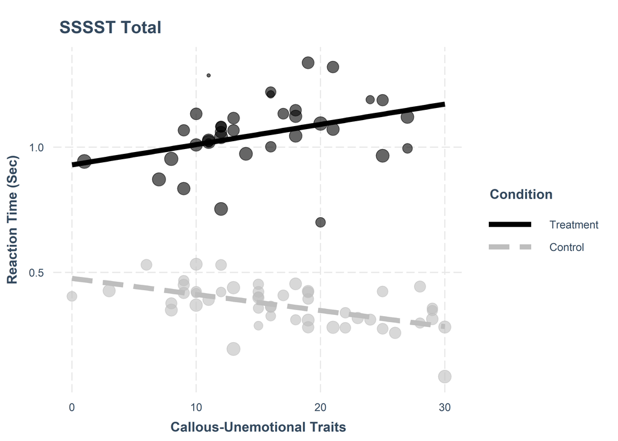

```r
m3_plot_mod <- lm(ssst_mean_rt ~
           sdq_cd +
           cu_total_sum +
           group_di +
           sex_male +
           iq +
           careless +
           sdq_hyperactivity +
           sdq_internalizing +
           cu_total_sum*sdq_cd +
           group_di*sdq_cd  +
           group_di*cu_total_sum  +
           group_di*cu_total_sum*sdq_cd , weights = ssst_sample_entropy_all,
         data = dat_sssst
)

m3_plot <- interactions::interact_plot(m3_plot_mod,
                            pred = cu_total_sum,
                            modx = group_di,
                            plot.points = TRUE,
                            point.size = TRUE,

                            y.label = "Reaction Time (Sec)",
                            x.label = "Callous-Unemotional Traits",
                            modx.labels = c("Control","Treatment"),
                            legend.main = "Condition",
                            line.thickness = 2,
                            partial.residuals = TRUE,
                            colors = c("grey","black"))
m3_plot_edit <- m3_plot + labs(title = "SSSST Total") +
  theme(
    plot.title = element_text(size = 10,
                            hjust = 0.5,
                            face="bold"
                            ),
    legend.position = "none"
    )

ggsave(
  paste0(base_fig,"\\rt_total_cond_cu.tiff"),
  plot = m3_plot_edit,
  device = "tiff",
  scale = 1,
  width = 3.5,
  height = 3,
  units = "in",
  dpi = 300
)

ggsave(
  paste0(base_fig,"\\rt_total_cond_cu_legend.tiff"),
  plot = m3_plot,
  device = "tiff",
  scale = 1,
  width = 5,
  height = 3,
  units = "in",
  dpi = 300
)

m3_plot + labs(title = "SSSST Total")
```

#### 4.2.1.4 Intercept/Slope by Condition

```r
m3_plot_vals <- interactions::sim_slopes(m3_plot_mod, pred = cu_total_sum, modx = group_di)
```

##### 4.2.1.4.1 Intercepts

```r
(m3_cond_intercepts <- m3_plot_vals$int[,c(1:3,6:7,4:5)])
```

| Value of group_di | Est. | S.E. | t val. | p | 2.5% | 97.5% |
| --- | --- | --- | --- | --- | --- | --- |
| 0 | 0.4736759 | 0.04939427 | 9.589692 | 1.682852e-14 | 0.3752102 | 0.5721416 |
| 1 | 0.9328272 | 0.06296633 | 14.814697 | 1.478353e-23 | 0.8073061 | 1.0583483 |

```r
write.csv(
  m3_cond_intercepts,
  paste0(base,"\\rt_total_cond_intercept_results.csv"),
  row.names=TRUE
  )
```

##### 4.2.1.4.2 Slopes

```r
(m3_cond_slopes <- m3_plot_vals$slopes[,c(1:3,6:7,4:5)])
```

| Value of group_di | Est. | S.E. | t val. | p | 2.5% | 97.5% |
| --- | --- | --- | --- | --- | --- | --- |
| 0 | -0.00613735 | 0.002570985 | -2.387159 | 0.01960707 | -0.0112625138 | -0.001012185 |
| 1 | 0.00855031 | 0.003946518 | 2.166545 | 0.03358019 | 0.0006830702 | 0.016417549 |

```r
write.csv(
  m3_cond_slopes,
  paste0(base,"\\rt_total_cond_slope_results.csv"),
  row.names=TRUE
  )
```

### 4.2.2 RT: go ~

#### 4.2.2.1 Model

```r
m4 <- lm(ssst_mean_rt_go ~
           sdq_cd +
           cu_total_mean +
           group_di +
           sex_male +
           iq +
           careless +
           sdq_hyperactivity +
           sdq_internalizing +
           int_cucd +
           int_cutest +
           int_cdtest +
           int_cucdtest ,
         data = dat_sssst
)
```

#### 4.2.2.2 Bootstrapped results

|  | Estimate | Std. Error | t value | Pr(>\|t\|) | 2.5% | 97.5% | boot_p | boot_t |
| --- | --- | --- | --- | --- | --- | --- | --- | --- |
| (Intercept) | 0.435 | 0.081 | 5.386 | 0.000 | 0.143 | 0.583 | 0.000 | 4.086 |
| sdq_cd | -0.027 | 0.010 | -2.566 | 0.012 | -0.063 | -0.010 | 0.049 | -1.998 |
| cu_total_mean | -0.027 | 0.051 | -0.536 | 0.594 | -0.113 | 0.053 | 0.525 | -0.638 |
| group_di | 0.635 | 0.027 | 23.420 | 0.000 | 0.581 | 0.675 | 0.000 | 4.086 |
| sex_male | 0.034 | 0.028 | 1.220 | 0.227 | 0.004 | 0.097 | 0.135 | 1.509 |
| iq | 0.000 | 0.001 | -0.626 | 0.533 | -0.002 | 0.002 | 0.688 | -0.403 |
| careless | -0.013 | 0.034 | -0.382 | 0.704 | -0.026 | 0.101 | 0.685 | -0.407 |
| sdq_hyperactivity | 0.002 | 0.007 | 0.244 | 0.808 | -0.004 | 0.018 | 0.761 | 0.305 |
| sdq_internalizing | 0.002 | 0.005 | 0.415 | 0.680 | -0.007 | 0.011 | 0.659 | 0.443 |
| int_cucd | -0.039 | 0.038 | -1.047 | 0.299 | -0.104 | 0.022 | 0.216 | -1.247 |

[output cut: 4 more lines]

#### 4.2.2.3 Figure

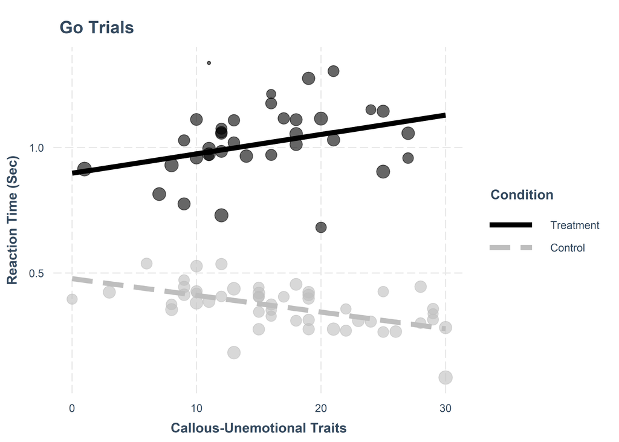

```r
m4_plot_mod <- lm(ssst_mean_rt_go ~
           sdq_cd +
           cu_total_sum +
           group_di +
           sex_male +
           iq +
           careless +
           sdq_hyperactivity +
           sdq_internalizing +
           cu_total_sum*sdq_cd +
           group_di*sdq_cd  +
           group_di*cu_total_sum  +
           group_di*cu_total_sum*sdq_cd , weights = ssst_sample_entropy_go,
         data = dat_sssst
)

m4_plot <- interactions::interact_plot(m4_plot_mod,
                            pred = cu_total_sum,
                            modx = group_di,
                            plot.points = TRUE,
                            point.size = TRUE,

                            y.label = "Reaction Time (Sec)",
                            x.label = "Callous-Unemotional Traits",
                            modx.labels = c("Control","Treatment"),
                            legend.main = "Condition",
                            line.thickness = 2,
                            partial.residuals = TRUE,
                            colors = c("grey","black"))
m4_plot_edit <- m4_plot + labs(title = "Go Trials") +
  theme(
    plot.title = element_text(size = 10,
                            hjust = 0.5,
                            face="bold"
                            ),
    legend.position = "none"
    )

ggsave(
  paste0(base_fig,"\\rt_go_cond_cu.tiff"),
  plot = m4_plot_edit,
  device = "tiff",
  scale = 1,
  width = 3.5,
  height = 3,
  units = "in",
  dpi = 300
)

ggsave(
  paste0(base_fig,"\\rt_go_cond_cu_legend.tiff"),
  plot = m4_plot,
  device = "tiff",
  scale = 1,
  width = 5,
  height = 3,
  units = "in",
  dpi = 300
)

m4_plot + labs(title = "Go Trials")
```

#### 4.2.2.4 Intercept/Slope by Condition

```r
m4_plot_vals <- interactions::sim_slopes(m4_plot_mod, pred = cu_total_sum, modx = group_di)
```

##### 4.2.2.4.1 Intercepts

```r
(m4_cond_intercepts <- m4_plot_vals$int[,c(1:3,6:7,4:5)])
```

| Value of group_di | Est. | S.E. | t val. | p | 2.5% | 97.5% |
| --- | --- | --- | --- | --- | --- | --- |
| 0 | 0.4726737 | 0.05154667 | 9.169821 | 1.009486e-13 | 0.3699173 | 0.5754301 |
| 1 | 0.9022939 | 0.06571950 | 13.729469 | 8.605824e-22 | 0.7712844 | 1.0333033 |

```r
write.csv(
  m4_cond_intercepts,
  paste0(base,"\\rt_go_cond_intercept_results.csv"),
  row.names=TRUE
  )
```

##### 4.2.2.4.2 Slopes

```r
(m4_cond_slopes <- m4_plot_vals$slopes[,c(1:3,6:7,4:5)])
```

| Value of group_di | Est. | S.E. | t val. | p | 2.5% | 97.5% |
| --- | --- | --- | --- | --- | --- | --- |
| 0 | -0.006160359 | 0.002684618 | -2.294687 | 0.02466882 | -0.0115120466 | -0.0008086705 |
| 1 | 0.008333881 | 0.004122148 | 2.021733 | 0.04692123 | 0.0001165298 | 0.0165512330 |

```r
write.csv(
  m4_cond_slopes,
  paste0(base,"\\rt_go_cond_slope_results.csv"),
  row.names=TRUE
  )
```

### 4.2.3 RT: Passive Control ~

- NOTE: as explained above - we recoded ignore RT trials so it is interpreted as:
  - higher = worse Control
  - lower = better Control

#### 4.2.3.1 Model

```r
m5 <- lm(ssst_mean_rt_ignore_rc ~
           sdq_cd +
           cu_total_mean +
           group_di +
           sex_male +
           iq +
           careless +
           sdq_hyperactivity +
           sdq_internalizing +
           int_cucd +
           int_cutest +
           int_cdtest +
           int_cucdtest,
         data = dat_sssst
)
```

#### 4.2.3.2 Bootstrapped results

```r
model <- m5
  ## extracting values
rt_ignore_coef <- coef(summary(model))
r2.adj_rt_ignore <- (1-((1.5-summary(model)$adj.r.squared)*(85-1)/(85-12-1)))

# bootstrapping
set.seed(1979)
aa<-simpleboot::lm.boot(model, R=1000, weights = runif(nrow(model.frame(model))))
rt_ignore_boot <- t(simpleboot::perc.lm(aa, p=c(0.025, 0.975)))

  ## adding bootstrapped ci to coefficients
rt_ignore_result <- cbind(rt_ignore_coef, rt_ignore_boot)

# Calculating bootstrap corrected p values
  # extracting bootstrapped values
p_v <- list()
ind <- 1
for(i in aa$boot.list){
  p_v[[ind]] <- ((as.data.frame(i$coef)[[1]]))
  ind <- ind+1
}
  # un-listing bootstrapped values for comparison
vals <- as.numeric(unlist(p_v))
  # extracting model estimates
obs <- as.data.frame(coef(summary(model)))$Estimate

  # Organizing and scaling bootstrapped values for p value calculation
df <- list()
for(i in seq(1,length(vals), by= length(model$coefficients))){
  chunk <- (vals[i:(i+length(model$coefficients)-1)])
  chunk_df <- as.data.frame(t(chunk))
  df <- rbind(df,chunk_df)
}
  # calculating bootstrap corrected p values
p_value <- sapply(1:length(obs), function(i) {
  mean(abs(scale(df[, i], scale=FALSE)) >= abs(obs[i]))
})

p_values <- data.frame(boot_p = p_value)
  # binding boot p values
rt_ignore_result <- cbind(rt_ignore_result,p_values)

# calculating bootstrap corrected t values
t_value <- list()
for(ii in p_value){
  if(ii > 0){
    t_value <- append(t_value,qt(ii/2, 85-1, lower.tail = FALSE))
  } else{
    t_value <- append(t_value,qt(0.0001/2, 85-1, lower.tail = FALSE))
  }
}

for(ii in 1:length(t_value)){
  if(obs[ii] < 0)(
    t_value[[ii]] <- (-1)*t_value[[ii]]
  )
}

t_values <- data.frame(boot_t = unlist(t_value))

  # binding boot t values
rt_ignore_result <- cbind(rt_ignore_result,t_values)



  # binding r2
r2 <- t(as.data.frame((c(r2.adj_rt_ignore,NA,NA,NA,NA,NA,NA, NA))))
rownames(r2) <- "Adj.R2"
colnames(r2) <- colnames(rt_ignore_result)
round(rt_ignore_result <- rbind(rt_ignore_result,r2), 3)
```

|  | Estimate | Std. Error | t value | Pr(>\|t\|) | 2.5% | 97.5% | boot_p | boot_t |
| --- | --- | --- | --- | --- | --- | --- | --- | --- |
| (Intercept) | 1.173 | 0.079 | 14.929 | 0.000 | 1.023 | 1.468 | 0.000 | 4.086 |
| sdq_cd | 0.023 | 0.010 | 2.252 | 0.027 | -0.001 | 0.064 | 0.190 | 1.321 |
| cu_total_mean | 0.026 | 0.050 | 0.513 | 0.609 | -0.082 | 0.097 | 0.535 | 0.623 |
| group_di | -0.778 | 0.026 | -29.452 | 0.000 | -0.835 | -0.719 | 0.000 | -4.086 |
| sex_male | -0.042 | 0.027 | -1.539 | 0.128 | -0.104 | 0.001 | 0.110 | -1.615 |
| iq | 0.000 | 0.001 | -0.514 | 0.609 | -0.003 | 0.001 | 0.750 | -0.320 |
| careless | 0.006 | 0.033 | 0.174 | 0.863 | -0.122 | 0.019 | 0.873 | 0.160 |
| sdq_hyperactivity | -0.004 | 0.006 | -0.623 | 0.535 | -0.019 | 0.008 | 0.549 | -0.602 |
| sdq_internalizing | -0.004 | 0.004 | -0.802 | 0.425 | -0.014 | 0.006 | 0.462 | -0.739 |
| int_cucd | 0.033 | 0.037 | 0.908 | 0.367 | -0.040 | 0.096 | 0.334 | 0.972 |

[output cut: 4 more lines]

```r
# saving results to csv
write.csv(
  rt_ignore_result,
  paste0(base,"\\rt_ignore_results.csv"),
  row.names=TRUE
  )
```

#### 4.2.3.3 Figure

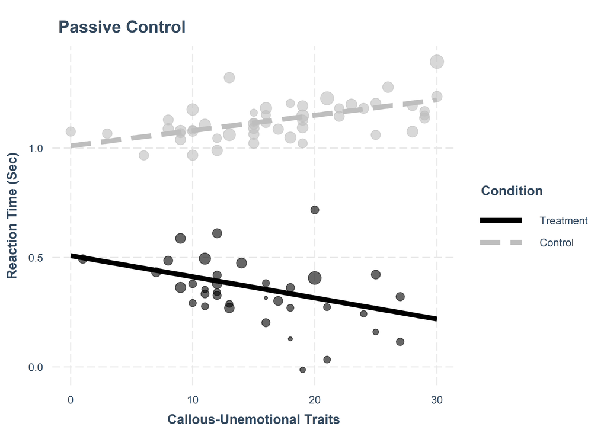

```r
m5_plot_mod <- lm(ssst_mean_rt_ignore_rc ~
           sdq_cd +
           cu_total_sum +
           group_di +
           sex_male +
           iq +
           careless +
           sdq_hyperactivity +
           sdq_internalizing +
           cu_total_sum*sdq_cd +
           group_di*sdq_cd  +
           group_di*cu_total_sum  +
           group_di*cu_total_sum*sdq_cd , weights = ssst_sample_entropy_ignore,
         data = dat_sssst
)

m5_plot <- interactions::interact_plot(m5_plot_mod,
                            pred = cu_total_sum,
                            modx = group_di,
                            plot.points = TRUE,
                            point.size = TRUE,
                            y.label = "Reaction Time (Sec)",
                            x.label = "Callous-Unemotional Traits",
                            modx.labels = c("Control","Treatment"),
                            legend.main = "Condition",
                            line.thickness = 2,
                            partial.residuals = TRUE,
                            colors = c("grey","black"))
m5_plot_edit <- m5_plot + labs(title = "Passive Control") +
  theme(
    plot.title = element_text(size = 10,
                            hjust = 0.5,
                            face="bold"
                            ),
    legend.position = "none"
    )

ggsave(
  paste0(base_fig,"\\rt_ignore_cond_cu.tiff"),
  plot = m5_plot_edit,
  device = "tiff",
  scale = 1,
  width = 3.5,
  height = 3,
  units = "in",
  dpi = 300
)

ggsave(
  paste0(base_fig,"\\rt_ignore_cond_cu_legend.tiff"),
  plot = m5_plot,
  device = "tiff",
  scale = 1,
  width = 5,
  height = 3,
  units = "in",
  dpi = 300
)

m5_plot + labs(title = "Passive Control")
```

#### 4.2.3.4 Intercept/Slope by Condition

```r
m5_plot_vals <- interactions::sim_slopes(m5_plot_mod, pred = cu_total_sum, modx = group_di)
```

##### 4.2.3.4.1 Intercepts

```r
(m5_cond_intercepts <- m5_plot_vals$int[,c(1:3,6:7,4:5)])
```

| Value of group_di | Est. | S.E. | t val. | p | 2.5% | 97.5% |
| --- | --- | --- | --- | --- | --- | --- |
| 0 | 1.0174022 | 0.05020538 | 20.264804 | 1.813973e-31 | 0.9173196 | 1.1174847 |
| 1 | 0.4817009 | 0.06417600 | 7.505936 | 1.277559e-10 | 0.3537684 | 0.6096334 |

```r
write.csv(
  m5_cond_intercepts,
  paste0(base,"\\rt_ignore_cond_intercept_results.csv"),
  row.names=TRUE
  )
```

##### 4.2.3.4.2 Slopes

```r
(m5_cond_slopes <- m5_plot_vals$slopes[,c(1:3,6:7,4:5)])
```

| Value of group_di | Est. | S.E. | t val. | p | 2.5% | 97.5% |
| --- | --- | --- | --- | --- | --- | --- |
| 0 | 0.006411439 | 0.002618253 | 2.448747 | 0.01677153 | 0.001192048 | 0.01163083 |
| 1 | -0.009187871 | 0.004016292 | -2.287650 | 0.02509764 | -0.017194202 | -0.00118154 |

```r
write.csv(
  m5_cond_slopes,
  paste0(base,"\\rt_ignore_cond_slope_results.csv"),
  row.names=TRUE
  )
```

### 4.2.4 RT: Selective Control ~

#### 4.2.4.1 Model

```r
m6 <- lm(ssst_mean_rt_stop ~
           sdq_cd +
           cu_total_mean +
           group_di +
           sex_male +
           iq +
           careless +
           sdq_hyperactivity +
           sdq_internalizing +
           int_cucd +
           int_cutest +
           int_cdtest +
           int_cucdtest,
         data = dat_sssst
)
```

#### 4.2.4.2 Bootstrapped results

```r
model <- m6
  ## extracting values
rt_stop_coef <- coef(summary(model))
r2.adj_rt_stop <- (1-((1.5-summary(model)$adj.r.squared)*(85-1)/(85-12-1)))

# bootstrapping
set.seed(1979)
aa<-simpleboot::lm.boot(model, R=1000, weights = runif(nrow(model.frame(model))))
rt_stop_boot <- t(simpleboot::perc.lm(aa, p=c(0.025, 0.975)))

  ## adding bootstrapped ci to coefficients
rt_stop_result <- cbind(rt_stop_coef, rt_stop_boot)

# Calculating bootstrap corrected p values
  # extracting bootstrapped values
p_v <- list()
ind <- 1
for(i in aa$boot.list){
  p_v[[ind]] <- ((as.data.frame(i$coef)[[1]]))
  ind <- ind+1
}
  # un-listing bootstrapped values for comparison
vals <- as.numeric(unlist(p_v))
  # extracting model estimates
obs <- as.data.frame(coef(summary(model)))$Estimate

  # Organizing and scaling bootstrapped values for p value calculation
df <- list()
for(i in seq(1,length(vals), by= length(model$coefficients))){
  chunk <- (vals[i:(i+length(model$coefficients)-1)])
  chunk_df <- as.data.frame(t(chunk))
  df <- rbind(df,chunk_df)
}
  # calculating bootstrap corrected p values
p_value <- sapply(1:length(obs), function(i) {
  mean(abs(scale(df[, i], scale=FALSE)) >= abs(obs[i]))**2
})

p_values <- data.frame(boot_p = p_value)
  # binding boot p values
rt_stop_result <- cbind(rt_stop_result,p_values)

# calculating bootstrap corrected t values
t_value <- list()
for(ii in p_value){
  if(ii > 0){
    t_value <- append(t_value,qt(ii/2, 85-1, lower.tail = FALSE))
  } else{
    t_value <- append(t_value,qt(0.0001/2, 85-1, lower.tail = FALSE))
  }
}

for(ii in 1:length(t_value)){
  if(obs[ii] < 0)(
    t_value[[ii]] <- (-1)*t_value[[ii]]
  )
}

t_values <- data.frame(boot_t = unlist(t_value))

  # binding boot t values
rt_stop_result <- cbind(rt_stop_result,t_values)




  # binding r2
r2 <- t(as.data.frame((c(r2.adj_rt_stop,NA,NA,NA,NA,NA,NA, NA))))
rownames(r2) <- "Adj.R2"
colnames(r2) <- colnames(rt_stop_result)
round(rt_stop_result <- rbind(rt_stop_result,r2), 3)
```

|  | Estimate | Std. Error | t value | Pr(>\|t\|) | 2.5% | 97.5% | boot_p | boot_t |
| --- | --- | --- | --- | --- | --- | --- | --- | --- |
| (Intercept) | 0.464 | 0.078 | 5.931 | 0.000 | 0.156 | 0.608 | 0.000 | 4.086 |
| sdq_cd | -0.026 | 0.010 | -2.545 | 0.013 | -0.056 | -0.005 | 0.003 | -3.079 |
| cu_total_mean | -0.021 | 0.050 | -0.415 | 0.680 | -0.114 | 0.061 | 0.417 | -0.815 |
| group_di | 0.684 | 0.026 | 26.003 | 0.000 | 0.633 | 0.727 | 0.000 | 4.086 |
| sex_male | 0.026 | 0.027 | 0.964 | 0.339 | -0.005 | 0.089 | 0.071 | 1.830 |
| iq | -0.001 | 0.001 | -1.058 | 0.293 | -0.002 | 0.002 | 0.241 | -1.181 |
| careless | -0.005 | 0.033 | -0.158 | 0.875 | -0.023 | 0.104 | 0.760 | -0.306 |
| sdq_hyperactivity | 0.005 | 0.006 | 0.768 | 0.445 | -0.002 | 0.019 | 0.135 | 1.510 |
| sdq_internalizing | -0.001 | 0.004 | -0.204 | 0.839 | -0.010 | 0.009 | 0.684 | -0.409 |
| int_cucd | -0.030 | 0.037 | -0.818 | 0.416 | -0.102 | 0.024 | 0.121 | -1.566 |

[output cut: 4 more lines]

```r
# saving results to csv
write.csv(
  rt_stop_result,
  paste0(base,"\\rt_stop_results.csv"),
  row.names=TRUE
  )
```

#### 4.2.4.3 Figure

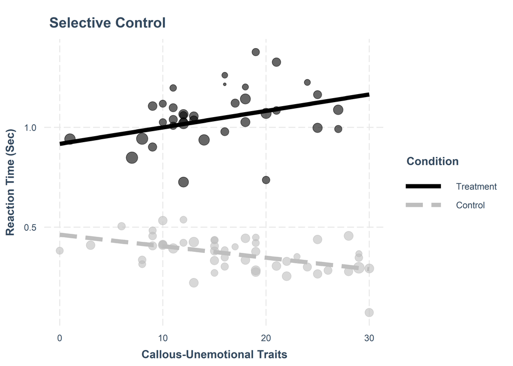

```r
m6_plot_mod <- lm(ssst_mean_rt_stop ~
           sdq_cd +
           cu_total_sum +
           group_di +
           sex_male +
           iq +
           careless +
           sdq_hyperactivity +
           sdq_internalizing +
           cu_total_sum*sdq_cd +
           group_di*sdq_cd  +
           group_di*cu_total_sum  +
           group_di*cu_total_sum*sdq_cd , weights = ssst_sample_entropy_stop,
         data = dat_sssst
)

m6_plot <- interactions::interact_plot(m6_plot_mod,
                            pred = cu_total_sum,
                            modx = group_di,
                            plot.points = TRUE,
                            point.size = TRUE,
                            y.label = "Reaction Time (Sec)",
                            x.label = "Callous-Unemotional Traits",
                            modx.labels = c("Control","Treatment"),
                            legend.main = "Condition",
                            line.thickness = 2,
                            partial.residuals = TRUE,
                            colors = c("grey","black"))
m6_plot_edit <- m6_plot + labs(title = "Selective Control") +
  theme(
    plot.title = element_text(size = 10,
                            hjust = 0.5,
                            face="bold"
                            ),
    legend.position = "none"
    )

ggsave(
  paste0(base_fig,"\\rt_stop_cond_cu.tiff"),
  plot = m6_plot_edit,
  device = "tiff",
  scale = 1,
  width = 3.5,
  height = 3,
  units = "in",
  dpi = 300
)

ggsave(
  paste0(base_fig,"\\rt_stop_cond_cu_legend.tiff"),
  plot = m6_plot,
  device = "tiff",
  scale = 1,
  width = 5,
  height = 3,
  units = "in",
  dpi = 300
)

m6_plot + labs(title = "Selective Control")
```

#### 4.2.4.4 Intercept/Slope by Condition

```r
m6_plot_vals <- interactions::sim_slopes(m6_plot_mod, pred = cu_total_sum, modx = group_di)
```

##### 4.2.4.4.1 Intercepts

```r
(m6_cond_intercepts <- m6_plot_vals$int[,c(1:3,6:7,4:5)])
```

| Value of group_di | Est. | S.E. | t val. | p | 2.5% | 97.5% |
| --- | --- | --- | --- | --- | --- | --- |
| 0 | 0.4675855 | 0.05049107 | 9.260756 | 6.842964e-14 | 0.3669334 | 0.5682376 |
| 1 | 0.9363395 | 0.06439015 | 14.541656 | 4.052283e-23 | 0.8079801 | 1.0646989 |

```r
write.csv(
  m6_cond_intercepts,
  paste0(base,"\\rt_stop_cond_intercept_results.csv"),
  row.names=TRUE
  )
```

##### 4.2.4.4.2 Slopes

```r
(m6_cond_slopes <- m6_plot_vals$slopes[,c(1:3,6:7,4:5)])
```

| Value of group_di | Est. | S.E. | t val. | p | 2.5% | 97.5% |
| --- | --- | --- | --- | --- | --- | --- |
| 0 | -0.005829106 | 0.002612146 | -2.231539 | 0.02875915 | -0.0110363233 | -0.0006218882 |
| 1 | 0.008517841 | 0.004003668 | 2.127509 | 0.03680321 | 0.0005366752 | 0.0164990075 |

```r
write.csv(
  m6_cond_slopes,
  paste0(base,"\\rt_stop_cond_slope_results.csv"),
  row.names=TRUE
  )
```

## 4.3 Reaction Time Contrasts

### 4.3.1 RT: Selective Control > Go ~

#### 4.3.1.1 Contrast calculation

```r
dat_sssst$contrast_rt_stop_go <- (
  (
    dat_sssst$ssst_mean_rt_stop -
      dat_sssst$ssst_mean_rt_go
    )
  /
    (
      (
        dat_sssst$ssst_mean_rt_stop +
          dat_sssst$ssst_mean_rt_go
        )/2
      )
  )
```

#### 4.3.1.2 Model

```r
ct1 <- lm(contrast_rt_stop_go ~
           sdq_cd +
           cu_total_mean +
           group_di +
           sex_male +
           iq +
           careless +
           sdq_hyperactivity +
           sdq_internalizing +
           int_cucd +
           int_cutest +
           int_cdtest +
           int_cucdtest ,
         data = dat_sssst
)
```

#### 4.3.1.3 Bootstrapped results

|  | Estimate | Std. Error | t value | Pr(>\|t\|) | 2.5% | 97.5% | boot_p | boot_t |
| --- | --- | --- | --- | --- | --- | --- | --- | --- |
| (Intercept) | 0.019 | 0.041 | 0.455 | 0.650 | -0.034 | 0.108 | 0.605 | 0.519 |
| sdq_cd | 0.001 | 0.005 | 0.099 | 0.921 | -0.016 | 0.010 | 0.957 | 0.054 |
| cu_total_mean | 0.014 | 0.026 | 0.535 | 0.595 | -0.034 | 0.053 | 0.539 | 0.617 |
| group_di | 0.039 | 0.014 | 2.808 | 0.006 | 0.009 | 0.063 | 0.005 | 2.883 |
| sex_male | -0.012 | 0.014 | -0.812 | 0.419 | -0.038 | 0.010 | 0.349 | -0.942 |
| iq | 0.000 | 0.000 | -0.430 | 0.669 | -0.001 | 0.001 | 0.620 | -0.498 |
| careless | 0.004 | 0.017 | 0.206 | 0.837 | -0.043 | 0.020 | 0.840 | 0.203 |
| sdq_hyperactivity | 0.005 | 0.003 | 1.476 | 0.144 | -0.002 | 0.008 | 0.072 | 1.822 |
| sdq_internalizing | -0.003 | 0.002 | -1.098 | 0.276 | -0.007 | 0.006 | 0.448 | -0.762 |
| int_cucd | 0.024 | 0.019 | 1.246 | 0.217 | -0.008 | 0.040 | 0.048 | 2.007 |

[output cut: 4 more lines]

#### 4.3.1.4 Figure

- Not significant so none needed

#### 4.3.1.5 Intercept/Slope by Condition

- Not significant so none needed

### 4.3.2 RT: Passive Control > Go

```r
dat_sssst$contrast_rt_ignore_go <- (
  (
    dat_sssst$ssst_mean_rt_ignore_rc -
      dat_sssst$ssst_mean_rt_go
    )
  /
    (
      (
        dat_sssst$ssst_mean_rt_ignore_rc +
          dat_sssst$ssst_mean_rt_go
        )/2
      )
  )
```

```r
ct2 <- lm(contrast_rt_ignore_go ~
           sdq_cd +
           cu_total_mean +
           group_di +
           sex_male +
           iq +
           careless +
           sdq_hyperactivity +
           sdq_internalizing +
           int_cucd +
           int_cutest +
           int_cdtest +
           int_cucdtest ,
         data = dat_sssst
)
```

#### 4.3.2.1 Bootstrapped results

|  | Estimate | Std. Error | t value | Pr(>\|t\|) | 2.5% | 97.5% | boot_p | boot_t |
| --- | --- | --- | --- | --- | --- | --- | --- | --- |
| (Intercept) | 1.020 | 0.219 | 4.649 | 0.000 | 0.606 | 1.850 | 0.000 | 5.279 |
| sdq_cd | 0.070 | 0.028 | 2.459 | 0.016 | 0.010 | 0.179 | 0.011 | 2.614 |
| cu_total_mean | 0.065 | 0.139 | 0.468 | 0.641 | -0.187 | 0.284 | 0.314 | 1.014 |
| group_di | -1.981 | 0.074 | -26.869 | 0.000 | -2.126 | -1.821 | 0.000 | -4.086 |
| sex_male | -0.107 | 0.076 | -1.408 | 0.163 | -0.278 | -0.006 | 0.016 | -2.462 |
| iq | 0.000 | 0.002 | -0.040 | 0.968 | -0.009 | 0.005 | 0.960 | -0.050 |
| careless | 0.019 | 0.093 | 0.203 | 0.840 | -0.316 | 0.050 | 0.716 | 0.365 |
| sdq_hyperactivity | -0.008 | 0.018 | -0.423 | 0.673 | -0.052 | 0.018 | 0.440 | -0.777 |
| sdq_internalizing | -0.009 | 0.012 | -0.736 | 0.464 | -0.036 | 0.017 | 0.226 | -1.221 |
| int_cucd | 0.101 | 0.103 | 0.989 | 0.326 | -0.087 | 0.271 | 0.069 | 1.844 |

[output cut: 4 more lines]

#### 4.3.2.2 Figure

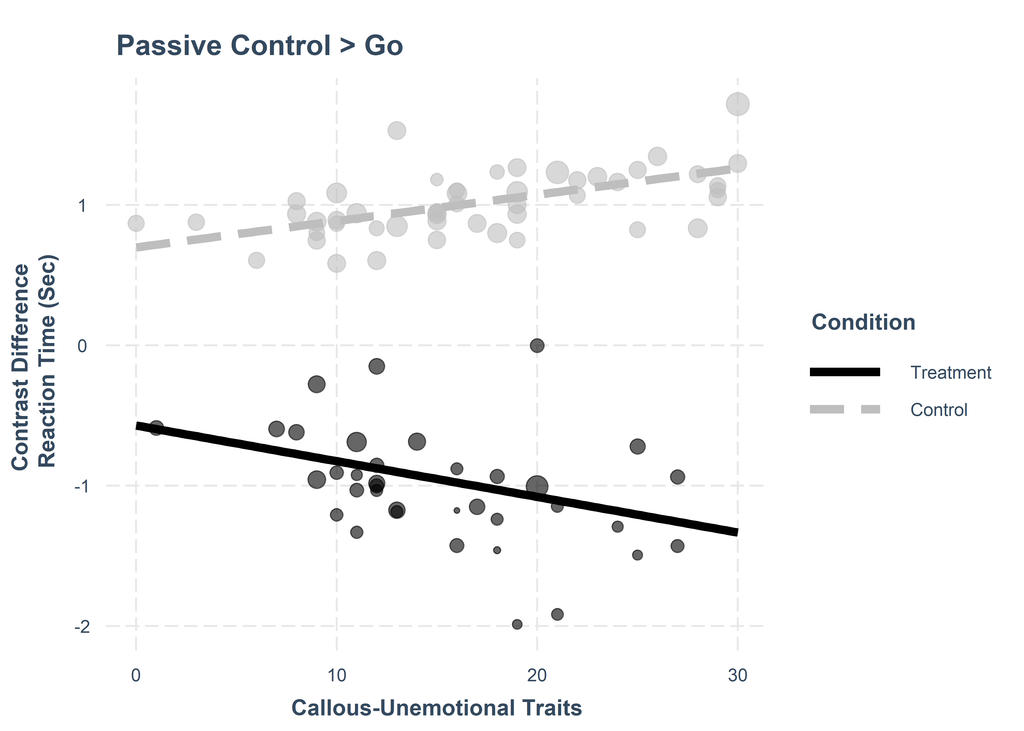

```r
ct2_plot_mod <- lm(contrast_rt_ignore_go ~
           sdq_cd +
           cu_total_sum +
           group_di +
           sex_male +
           iq +
           careless +
           sdq_hyperactivity +
           sdq_internalizing +
           cu_total_sum*sdq_cd +
           group_di*sdq_cd  +
           group_di*cu_total_sum  +
           group_di*cu_total_sum*sdq_cd , weights = ssst_sample_entropy_ignore,
         data = dat_sssst
)

ct2_plot <- interactions::interact_plot(ct2_plot_mod,
                            pred = cu_total_sum,
                            modx = group_di,
                            plot.points = TRUE,
                            point.size = TRUE,
                            y.label = "Contrast Difference \n Reaction Time (Sec)",
                            x.label = "Callous-Unemotional Traits",
                            modx.labels = c("Control","Treatment"),
                            legend.main = "Condition",
                            line.thickness = 2,
                            partial.residuals = TRUE,
                            colors = c("grey","black"))
ct2_plot_edit <- ct2_plot + labs(title = "Passive Control > Go") +
  theme(
    plot.title = element_text(size = 10,
                            hjust = 0.5,
                            face="bold"
                            ),
    legend.position = "none"
    )

ggsave(
  paste0(base_fig,"\\rt_contrast_ignore_go_cond_cu.tiff"),
  plot = ct2_plot_edit,
  device = "tiff",
  scale = 1,
  width = 3.5,
  height = 3,
  units = "in",
  dpi = 300
)

ggsave(
  paste0(base_fig,"\\rt_contrast_ignore_go_cond_cu_legend.tiff"),
  plot = ct2_plot,
  device = "tiff",
  scale = 1,
  width = 5,
  height = 3,
  units = "in",
  dpi = 300
)

ct2_plot + labs(title = "Passive Control > Go")
```

#### 4.3.2.3 Intercept/Slope by Condition

```r
ct2_plot_vals <- interactions::sim_slopes(ct2_plot_mod, pred = cu_total_sum, modx = group_di)
```

##### 4.3.2.3.1 Intercepts

```r
(ct2_cond_intercepts <- ct2_plot_vals$int[,c(1:3,6:7,4:5)])
```

| Value of group_di | Est. | S.E. | t val. | p | 2.5% | 97.5% |
| --- | --- | --- | --- | --- | --- | --- |
| 0 | 0.7173374 | 0.1401596 | 5.118003 | 2.470259e-06 | 0.4379343 | 0.9967405 |
| 1 | -0.6296332 | 0.1791618 | -3.514328 | 7.664303e-04 | -0.9867856 | -0.2724807 |

```r
write.csv(
  ct2_cond_intercepts,
  paste0(base,"\\rt_contrast_ignore_go_cond_intercept_results.csv"),
  row.names=TRUE
  )
```

##### 4.3.2.3.2 Slopes

```r
(ct2_cond_slopes <- ct2_plot_vals$slopes[,c(1:3,6:7,4:5)])
```

| Value of group_di | Est. | S.E. | t val. | p | 2.5% | 97.5% |
| --- | --- | --- | --- | --- | --- | --- |
| 0 | 0.01731335 | 0.007309443 | 2.368627 | 0.02054023 | 0.002742238 | 0.031884455 |
| 1 | -0.02493720 | 0.011212384 | -2.224077 | 0.02927989 | -0.047288683 | -0.002585725 |

```r
write.csv(
  ct2_cond_slopes,
  paste0(base,"\\rt_contrast_ignore_go_cond_slope_results.csv"),
  row.names=TRUE
  )
```

### 4.3.3 RT: Selective > Passive Control

#### 4.3.3.1 Considerations for metric

- Selective > reverse coded passive control trials contrast can be interpreted as:
  - Comparisons on selective control performance to speed of passive control
  - Higher = Slower processing during selective control
  - Lower = Faster processing during selective control

```r
dat_sssst$contrast_rt_stop_ignore <- (
  (
    dat_sssst$ssst_mean_rt_stop -
      dat_sssst$ssst_mean_rt_ignore_rc
    )
  /
    (
      (
        dat_sssst$ssst_mean_rt_stop +
          dat_sssst$ssst_mean_rt_ignore_rc
        )/2
      )
  )
```

```r
ct3 <- lm(contrast_rt_stop_ignore ~
           sdq_cd +
           cu_total_mean +
           group_di +
           sex_male +
           iq +
           careless +
           sdq_hyperactivity +
           sdq_internalizing +
           int_cucd +
           int_cutest +
           int_cdtest +
           int_cucdtest ,
         data = dat_sssst
)
```

#### 4.3.3.2 Bootstrapped results

|  | Estimate | Std. Error | t value | Pr(>\|t\|) | 2.5% | 97.5% | boot_p | boot_t |
| --- | --- | --- | --- | --- | --- | --- | --- | --- |
| (Intercept) | -1.007 | 0.211 | -4.763 | 0.000 | -1.815 | -0.608 | 0.000 | -5.279 |
| sdq_cd | -0.067 | 0.027 | -2.460 | 0.016 | -0.165 | -0.005 | 0.010 | -2.643 |
| cu_total_mean | -0.063 | 0.134 | -0.468 | 0.641 | -0.266 | 0.194 | 0.334 | -0.972 |
| group_di | 2.013 | 0.071 | 28.344 | 0.000 | 1.864 | 2.149 | 0.000 | 4.086 |
| sex_male | 0.099 | 0.073 | 1.351 | 0.181 | 0.000 | 0.259 | 0.020 | 2.368 |
| iq | 0.000 | 0.002 | -0.019 | 0.985 | -0.005 | 0.008 | 0.980 | -0.025 |
| careless | -0.015 | 0.089 | -0.162 | 0.871 | -0.046 | 0.307 | 0.769 | -0.294 |
| sdq_hyperactivity | 0.011 | 0.017 | 0.640 | 0.524 | -0.015 | 0.050 | 0.239 | 1.186 |
| sdq_internalizing | 0.007 | 0.012 | 0.614 | 0.541 | -0.017 | 0.034 | 0.280 | 1.088 |
| int_cucd | -0.085 | 0.099 | -0.862 | 0.392 | -0.259 | 0.098 | 0.119 | -1.575 |

[output cut: 4 more lines]

#### 4.3.3.3 Figure

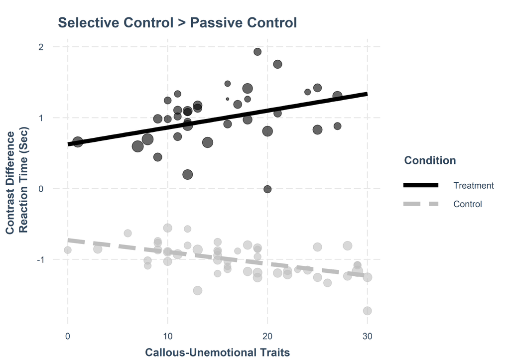

```r
ct3_plot_mod <- lm(contrast_rt_stop_ignore ~
           sdq_cd +
           cu_total_sum +
           group_di +
           sex_male +
           iq +
           careless +
           sdq_hyperactivity +
           sdq_internalizing +
           cu_total_sum*sdq_cd +
           group_di*sdq_cd  +
           group_di*cu_total_sum  +
           group_di*cu_total_sum*sdq_cd,
           weights = ssst_sample_entropy_stop,
         data = dat_sssst
)

ct3_plot <- interactions::interact_plot(ct3_plot_mod,
                            pred = cu_total_sum,
                            modx = group_di,
                            plot.points = TRUE,
                            point.size = TRUE,
                            y.label = "Contrast Difference \n Reaction Time (Sec)",
                            x.label = "Callous-Unemotional Traits",
                            modx.labels = c("Control","Treatment"),
                            legend.main = "Condition",
                            line.thickness = 2,
                            partial.residuals = TRUE,
                            colors = c("grey","black"))
ct3_plot_edit <- ct3_plot + labs(title = "Selective Control > Passive Control") +
  theme(
    plot.title = element_text(size = 10,
                            hjust = 0.5,
                            face="bold"
                            ),
    legend.position = "none"
    )

ggsave(
  paste0(base_fig,"\\rt_contrast_stop_ignore_cond_cu.tiff"),
  plot = ct3_plot_edit,
  device = "tiff",
  scale = 1,
  width = 3.5,
  height = 3,
  units = "in",
  dpi = 300
)

ggsave(
  paste0(base_fig,"\\rt_contrast_stop_ignore_cond_cu_legend.tiff"),
  plot = ct3_plot,
  device = "tiff",
  scale = 1,
  width = 5,
  height = 3,
  units = "in",
  dpi = 300
)

ct3_plot + labs(title = "Selective Control > Passive Control")
```

#### 4.3.3.4 Intercept/Slope by Condition

```r
ct3_plot_vals <- interactions::sim_slopes(ct3_plot_mod, pred = cu_total_sum, modx = group_di)
```

##### 4.3.3.4.1 Intercepts

```r
(ct3_cond_intercepts <- ct3_plot_vals$int[,c(1:3,6:7,4:5)])
```

| Value of group_di | Est. | S.E. | t val. | p | 2.5% | 97.5% |
| --- | --- | --- | --- | --- | --- | --- |
| 0 | -0.7172017 | 0.1362920 | -5.262246 | 1.406395e-06 | -0.9888948 | -0.4455087 |
| 1 | 0.6592842 | 0.1738101 | 3.793128 | 3.069313e-04 | 0.3128000 | 1.0057684 |

```r
write.csv(
  ct3_cond_intercepts,
  paste0(base,"\\rt_contrast_stop_ignore_cond_intercept_results.csv"),
  row.names=TRUE
  )
```

##### 4.3.3.4.2 Slopes

```r
(ct3_cond_slopes <- ct3_plot_vals$slopes[,c(1:3,6:7,4:5)])
```

| Value of group_di | Est. | S.E. | t val. | p | 2.5% | 97.5% |
| --- | --- | --- | --- | --- | --- | --- |
| 0 | -0.01688770 | 0.007051038 | -2.395066 | 0.01922055 | -0.03094369 | -0.002831717 |
| 1 | 0.02450347 | 0.010807213 | 2.267326 | 0.02637337 | 0.00295969 | 0.046047260 |

```r
write.csv(
  ct3_cond_slopes,
  paste0(base,"\\rt_contrast_stop_ignore_cond_slope_results.csv"),
  row.names=TRUE
  )
```

# 5 Secondary Analyses

## 5.1 Accuracy (ACC)

### 5.1.1 ACC: Overall ~

#### 5.1.1.1 Model

```r
cm3 <- lm(ssst_correct ~
             sdq_cd +
             cu_total_mean +
             group_di +
             sex_male +
             iq +
             careless +
             sdq_hyperactivity +
             sdq_internalizing +
             int_cucd +
             int_cutest +
             int_cdtest +
             int_cucdtest,
           data = dat_sssst
)
```

#### 5.1.1.2 Bootstrapped results

|  | Estimate | Std. Error | t value | Pr(>\|t\|) | 2.5% | 97.5% | boot_p | boot_t |
| --- | --- | --- | --- | --- | --- | --- | --- | --- |
| (Intercept) | 418.289 | 18.602 | 22.486 | 0.000 | 379.659 | 464.081 | 0.000 | 4.086 |
| sdq_cd | 2.428 | 2.411 | 1.007 | 0.317 | -0.194 | 9.786 | 0.272 | 1.106 |
| cu_total_mean | -3.017 | 11.807 | -0.255 | 0.799 | -21.718 | 20.072 | 0.777 | -0.284 |
| group_di | -164.798 | 6.252 | -26.361 | 0.000 | -169.598 | -149.305 | 0.000 | -4.086 |
| sex_male | 0.086 | 6.467 | 0.013 | 0.989 | -17.503 | 4.463 | 0.993 | 0.009 |
| iq | 0.185 | 0.183 | 1.008 | 0.317 | -0.218 | 0.648 | 0.385 | 0.873 |
| careless | 9.781 | 7.862 | 1.244 | 0.218 | -14.613 | 17.757 | 0.247 | 1.166 |
| sdq_hyperactivity | 0.820 | 1.507 | 0.544 | 0.588 | -2.469 | 1.741 | 0.442 | 0.772 |
| sdq_internalizing | 0.444 | 1.040 | 0.427 | 0.670 | -1.479 | 2.201 | 0.608 | 0.515 |
| int_cucd | 5.341 | 8.693 | 0.614 | 0.541 | -2.791 | 19.116 | 0.327 | 0.986 |

[output cut: 4 more lines]

#### 5.1.1.3 Figure

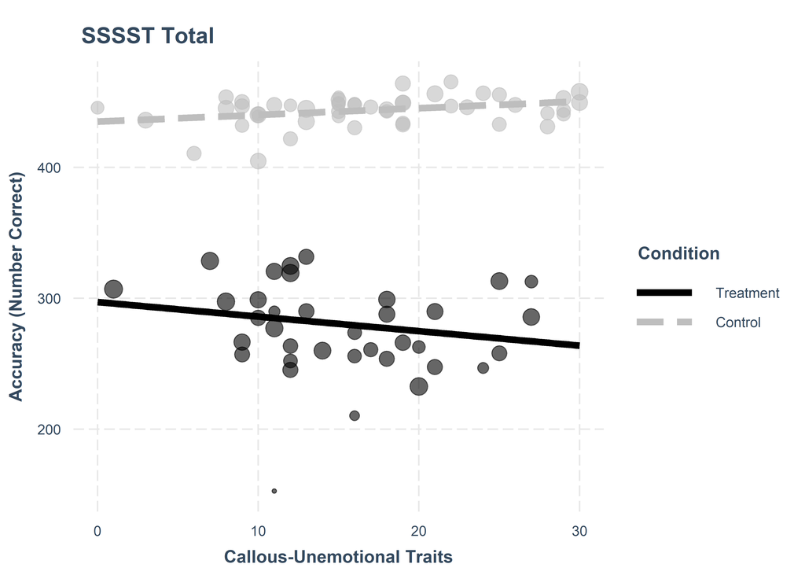

```r
cm3_plot_mod <- lm(ssst_correct ~
           sdq_cd +
           cu_total_sum +
           group_di +
           sex_male +
           iq +
           careless +
           sdq_hyperactivity +
           sdq_internalizing +
           cu_total_sum*sdq_cd +
           group_di*sdq_cd  +
           group_di*cu_total_sum  +
           group_di*cu_total_sum*sdq_cd , weights = ssst_sample_entropy_all,
         data = dat_sssst
)

cm3_plot <- interactions::interact_plot(cm3_plot_mod,
                            pred = cu_total_sum,
                            modx = group_di,
                            plot.points = TRUE,
                            point.size = TRUE,
                            y.label = "Accuracy (Number Correct)",
                            x.label = "Callous-Unemotional Traits",
                            modx.labels = c("Control","Treatment"),
                            legend.main = "Condition",
                            line.thickness = 2,
                            partial.residuals = TRUE,
                            colors = c("grey","black"))
cm3_plot_edit <- cm3_plot + labs(title = "SSSST Total") +
  theme(
    plot.title = element_text(size = 10,
                            hjust = 0.5,
                            face="bold"
                            ),
    legend.position = "none"
    )

ggsave(
  paste0(base_fig,"\\acc_total_cond_cu.tiff"),
  plot = cm3_plot_edit,
  device = "tiff",
  scale = 1,
  width = 3.5,
  height = 3,
  units = "in",
  dpi = 300
)

ggsave(
  paste0(base_fig,"\\acc_total_cond_cu_legend.tiff"),
  plot = cm3_plot,
  device = "tiff",
  scale = 1,
  width = 5,
  height = 3,
  units = "in",
  dpi = 300
)

cm3_plot + labs(title = "SSSST Total")
```

#### 5.1.1.4 Intercept/Slope by Condition

```r
cm3_plot_vals <- interactions::sim_slopes(cm3_plot_mod, pred = cu_total_sum, modx = group_di)
```

##### 5.1.1.4.1 Intercepts

```r
(cm3_cond_intercepts <- cm3_plot_vals$int[,c(1:3,6:7,4:5)])
```

| Value of group_di | Est. | S.E. | t val. | p | 2.5% | 97.5% |
| --- | --- | --- | --- | --- | --- | --- |
| 0 | 435.687 | 11.89443 | 36.62950 | 2.714473e-48 | 411.9759 | 459.3981 |
| 1 | 294.786 | 15.16266 | 19.44157 | 2.278840e-30 | 264.5597 | 325.0122 |

```r
write.csv(
  cm3_cond_intercepts,
  paste0(base,"\\acc_total_cond_intercept_results.csv"),
  row.names=TRUE
  )
```

##### 5.1.1.4.2 Slopes

```r
(cm3_cond_slopes <- cm3_plot_vals$slopes[,c(1:3,6:7,4:5)])
```

| Value of group_di | Est. | S.E. | t val. | p | 2.5% | 97.5% |
| --- | --- | --- | --- | --- | --- | --- |
| 0 | 0.4510073 | 0.6191080 | 0.7284792 | 0.4686831 | -0.783162 | 1.6851767 |
| 1 | -1.2633994 | 0.9503444 | -1.3294121 | 0.1879090 | -3.157876 | 0.6310776 |

```r
write.csv(
  cm3_cond_slopes,
  paste0(base,"\\acc_total_cond_slope_results.csv"),
  row.names=TRUE
  )
```

### 5.1.2 ACC: go ~

#### 5.1.2.1 Model

```r
cm4 <- lm(ssst_correct_go ~
           sdq_cd +
           cu_total_mean +
           group_di +
           sex_male +
           iq +
           careless +
           sdq_hyperactivity +
           sdq_internalizing +
           int_cucd +
           int_cutest +
           int_cdtest +
           int_cucdtest ,
         data = dat_sssst
)
```

#### 5.1.2.2 Bootstrapped results

|  | Estimate | Std. Error | t value | Pr(>\|t\|) | 2.5% | 97.5% | boot_p | boot_t |
| --- | --- | --- | --- | --- | --- | --- | --- | --- |
| (Intercept) | 260.741 | 17.761 | 14.681 | 0.000 | 231.837 | 310.323 | 0.000 | 4.086 |
| sdq_cd | 5.220 | 2.302 | 2.268 | 0.026 | 4.008 | 11.800 | 0.019 | 2.392 |
| cu_total_mean | -9.266 | 11.273 | -0.822 | 0.414 | -29.111 | 4.748 | 0.251 | -1.156 |
| group_di | -68.672 | 5.969 | -11.505 | 0.000 | -72.346 | -54.482 | 0.000 | -4.086 |
| sex_male | -0.379 | 6.174 | -0.061 | 0.951 | -15.325 | 3.723 | 0.942 | -0.073 |
| iq | 0.025 | 0.175 | 0.144 | 0.886 | -0.398 | 0.454 | 0.913 | 0.110 |
| careless | 10.012 | 7.507 | 1.334 | 0.186 | -14.011 | 14.093 | 0.192 | 1.315 |
| sdq_hyperactivity | 0.603 | 1.439 | 0.419 | 0.676 | -2.539 | 1.114 | 0.502 | 0.674 |
| sdq_internalizing | -0.332 | 0.993 | -0.334 | 0.739 | -2.186 | 1.270 | 0.684 | -0.408 |
| int_cucd | 3.316 | 8.300 | 0.400 | 0.691 | -3.923 | 12.531 | 0.407 | 0.833 |

[output cut: 4 more lines]

#### 5.1.2.3 Figure

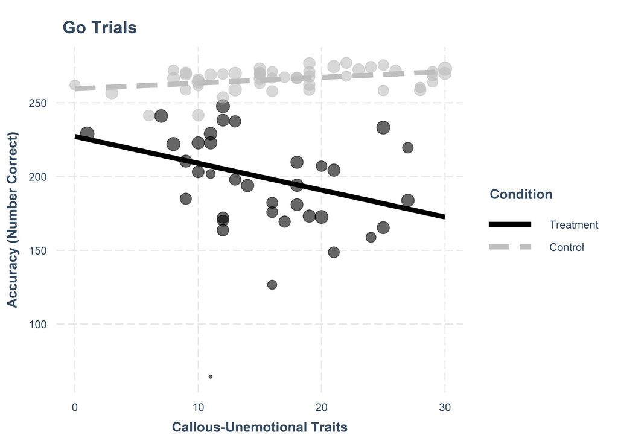

```r
cm4_plot_mod <- lm(ssst_correct_go ~
           sdq_cd +
           cu_total_sum +
           group_di +
           sex_male +
           iq +
           careless +
           sdq_hyperactivity +
           sdq_internalizing +
           cu_total_sum*sdq_cd +
           group_di*sdq_cd  +
           group_di*cu_total_sum  +
           group_di*cu_total_sum*sdq_cd , weights = ssst_sample_entropy_go,
         data = dat_sssst
)

cm4_plot <- interactions::interact_plot(cm4_plot_mod,
                            pred = cu_total_sum,
                            modx = group_di,
                            plot.points = TRUE,
                            point.size = TRUE,
                            y.label = "Accuracy (Number Correct)",
                            x.label = "Callous-Unemotional Traits",
                            modx.labels = c("Control","Treatment"),
                            legend.main = "Condition",
                            line.thickness = 2,
                            partial.residuals = TRUE,
                            colors = c("grey","black"))
cm4_plot_edit <- cm4_plot + labs(title = "Go Trials") +
  theme(
    plot.title = element_text(size = 10,
                            hjust = 0.5,
                            face="bold"
                            ),
    legend.position = "none"
    )

ggsave(
  paste0(base_fig,"\\acc_go_cond_cu.tiff"),
  plot = cm4_plot_edit,
  device = "tiff",
  scale = 1,
  width = 3.5,
  height = 3,
  units = "in",
  dpi = 300
)

ggsave(
  paste0(base_fig,"\\acc_go_cond_cu_legend.tiff"),
  plot = cm4_plot,
  device = "tiff",
  scale = 1,
  width = 5,
  height = 3,
  units = "in",
  dpi = 300
)

cm4_plot + labs(title = "Go Trials")
```

#### 5.1.2.4 Intercept/Slope by Condition

```r
cm4_plot_vals <- interactions::sim_slopes(cm4_plot_mod, pred = cu_total_sum, modx = group_di)
```

##### 5.1.2.4.1 Intercepts

```r
(cm4_cond_intercepts <- cm4_plot_vals$int[,c(1:3,6:7,4:5)])
```

| Value of group_di | Est. | S.E. | t val. | p | 2.5% | 97.5% |
| --- | --- | --- | --- | --- | --- | --- |
| 0 | 259.3125 | 11.34495 | 22.85709 | 9.883400e-35 | 236.6968 | 281.9283 |
| 1 | 224.4812 | 14.46426 | 15.51972 | 1.143171e-24 | 195.6472 | 253.3152 |

```r
write.csv(
  cm4_cond_intercepts,
  paste0(base,"\\acc_go_cond_intercept_results.csv"),
  row.names=TRUE
  )
```

##### 5.1.2.4.2 Slopes

```r
(cm4_cond_slopes <- cm4_plot_vals$slopes[,c(1:3,6:7,4:5)])
```

| Value of group_di | Est. | S.E. | t val. | p | 2.5% | 97.5% |
| --- | --- | --- | --- | --- | --- | --- |
| 0 | 0.3721226 | 0.5908599 | 0.6297984 | 0.53082008 | -0.805735 | 1.5499802 |
| 1 | -2.0108215 | 0.9072471 | -2.2163990 | 0.02982431 | -3.819385 | -0.2022576 |

```r
write.csv(
  cm4_cond_slopes,
  paste0(base,"\\acc_go_cond_slope_results.csv"),
  row.names=TRUE
  )
```

### 5.1.3 ACC: Passive Control ~

- NOTE: as explained above - we recoded ignore acc trials so it is interpreted as:
  - higher = worse control
  - lower = better control

#### 5.1.3.1 Model

```r
cm5 <- lm(ssst_correct_ignore ~
           sdq_cd +
           cu_total_mean +
           group_di +
           sex_male +
           iq +
           careless +
           sdq_hyperactivity +
           sdq_internalizing +
           int_cucd +
           int_cutest +
           int_cdtest +
           int_cucdtest,
         data = dat_sssst
)
```

#### 5.1.3.2 Bootstrapped results

|  | Estimate | Std. Error | t value | Pr(>\|t\|) | 2.5% | 97.5% | boot_p | boot_t |
| --- | --- | --- | --- | --- | --- | --- | --- | --- |
| (Intercept) | 75.090 | 6.007 | 12.501 | 0.000 | 51.376 | 84.378 | 0.000 | 4.086 |
| sdq_cd | -2.744 | 0.778 | -3.525 | 0.001 | -5.239 | -1.416 | 0.003 | -3.057 |
| cu_total_mean | 7.532 | 3.813 | 1.975 | 0.052 | 5.711 | 19.192 | 0.036 | 2.131 |
| group_di | -40.340 | 2.019 | -19.983 | 0.000 | -44.713 | -36.454 | 0.000 | -4.086 |
| sex_male | 1.544 | 2.088 | 0.739 | 0.462 | -1.523 | 6.507 | 0.431 | 0.791 |
| iq | 0.093 | 0.059 | 1.579 | 0.119 | -0.025 | 0.303 | 0.241 | 1.181 |
| careless | -1.202 | 2.539 | -0.473 | 0.637 | -2.826 | 7.765 | 0.636 | -0.475 |
| sdq_hyperactivity | 0.044 | 0.487 | 0.091 | 0.928 | -0.977 | 0.880 | 0.928 | 0.091 |
| sdq_internalizing | 0.600 | 0.336 | 1.787 | 0.078 | -0.009 | 1.393 | 0.100 | 1.663 |
| int_cucd | 0.753 | 2.807 | 0.268 | 0.789 | -2.030 | 5.041 | 0.639 | 0.471 |

[output cut: 4 more lines]

#### 5.1.3.3 Figure

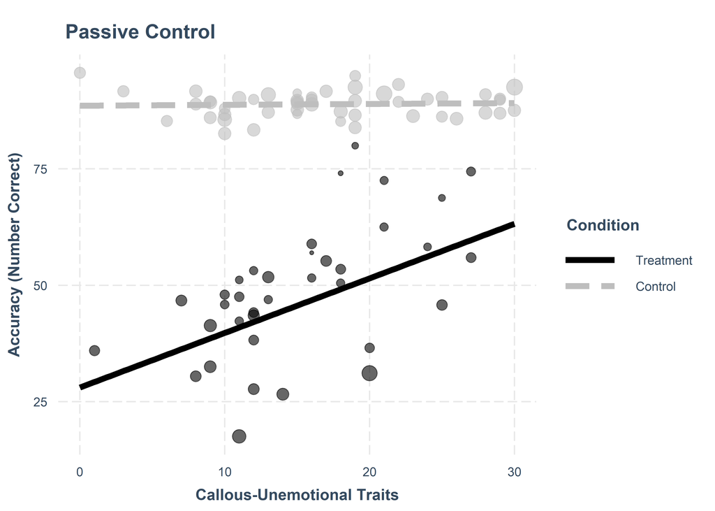

```r
cm5_plot_mod <- lm(ssst_correct_ignore ~
           sdq_cd +
           cu_total_sum +
           group_di +
           sex_male +
           iq +
           careless +
           sdq_hyperactivity +
           sdq_internalizing +
           cu_total_sum*sdq_cd +
           group_di*sdq_cd  +
           group_di*cu_total_sum  +
           group_di*cu_total_sum*sdq_cd , weights = ssst_sample_entropy_ignore,
         data = dat_sssst
)

cm5_plot <- interactions::interact_plot(cm5_plot_mod,
                            pred = cu_total_sum,
                            modx = group_di,
                            plot.points = TRUE,
                            point.size = TRUE,
                            y.label = "Accuracy (Number Correct)",
                            x.label = "Callous-Unemotional Traits",
                            modx.labels = c("Control","Treatment"),
                            legend.main = "Condition",
                            line.thickness = 2,
                            partial.residuals = TRUE,
                            colors = c("grey","black"))
cm5_plot_edit <- cm5_plot + labs(title = "Passive Control") +
  theme(
    plot.title = element_text(size = 10,
                            hjust = 0.5,
                            face="bold"
                            ),
    legend.position = "none"
    )

ggsave(
  paste0(base_fig,"\\acc_ignore_cond_cu.tiff"),
  plot = cm5_plot_edit,
  device = "tiff",
  scale = 1,
  width = 3.5,
  height = 3,
  units = "in",
  dpi = 300
)

ggsave(
  paste0(base_fig,"\\acc_ignore_cond_cu_legend.tiff"),
  plot = cm5_plot,
  device = "tiff",
  scale = 1,
  width = 5,
  height = 3,
  units = "in",
  dpi = 300
)

cm5_plot + labs(title = "Passive Control")
```

#### 5.1.3.4 Intercept/Slope by Condition

```r
cm5_plot_vals <- interactions::sim_slopes(cm5_plot_mod, pred = cu_total_sum, modx = group_di)
```

##### 5.1.3.4.1 Intercepts

```r
(cm5_cond_intercepts <- cm5_plot_vals$int[,c(1:3,6:7,4:5)])
```

| Value of group_di | Est. | S.E. | t val. | p | 2.5% | 97.5% |
| --- | --- | --- | --- | --- | --- | --- |
| 0 | 89.14089 | 3.837345 | 23.229837 | 3.537334e-35 | 81.49128 | 96.79050 |
| 1 | 32.31355 | 4.905160 | 6.587666 | 6.306619e-09 | 22.53530 | 42.09181 |

```r
write.csv(
  cm5_cond_intercepts,
  paste0(base,"\\acc_ignore_cond_intercept_results.csv"),
  row.names=TRUE
  )
```

##### 5.1.3.4.2 Slopes

```r
(cm5_cond_slopes <- cm5_plot_vals$slopes[,c(1:3,6:7,4:5)])
```

| Value of group_di | Est. | S.E. | t val. | p | 2.5% | 97.5% |
| --- | --- | --- | --- | --- | --- | --- |
| 0 | -0.009362605 | 0.2001207 | -0.04678478 | 0.9628142845 | -0.4082960 | 0.3895708 |
| 1 | 1.082811037 | 0.3069770 | 3.52733636 | 0.0007350594 | 0.4708636 | 1.6947584 |

```r
write.csv(
  cm5_cond_slopes,
  paste0(base,"\\acc_ignore_cond_slope_results.csv"),
  row.names=TRUE
  )
```

### 5.1.4 ACC: Selective Control ~

#### 5.1.4.1 Model

```r
cm6 <- lm(ssst_correct_stop ~
           sdq_cd +
           cu_total_mean +
           group_di +
           sex_male +
           iq +
           careless +
           sdq_hyperactivity +
           sdq_internalizing +
           int_cucd +
           int_cutest +
           int_cdtest +
           int_cucdtest,
         data = dat_sssst
)
```

#### 5.1.4.2 Bootstrapped results

|  | Estimate | Std. Error | t value | Pr(>\|t\|) | 2.5% | 97.5% | boot_p | boot_t |
| --- | --- | --- | --- | --- | --- | --- | --- | --- |
| (Intercept) | 82.458 | 3.788 | 21.766 | 0.000 | 75.473 | 95.240 | 0.000 | 4.086 |
| sdq_cd | -0.048 | 0.491 | -0.099 | 0.922 | -1.172 | 1.046 | 0.828 | -0.218 |
| cu_total_mean | -1.283 | 2.405 | -0.534 | 0.595 | -6.080 | 4.118 | 0.339 | -0.962 |
| group_di | -55.786 | 1.273 | -43.817 | 0.000 | -58.027 | -52.760 | 0.000 | -4.086 |
| sex_male | -1.078 | 1.317 | -0.819 | 0.416 | -5.279 | 0.000 | 0.174 | -1.371 |
| iq | 0.066 | 0.037 | 1.772 | 0.081 | -0.053 | 0.131 | 0.025 | 2.283 |
| careless | 0.971 | 1.601 | 0.606 | 0.546 | -3.869 | 2.417 | 0.267 | 1.117 |
| sdq_hyperactivity | 0.173 | 0.307 | 0.564 | 0.575 | -0.210 | 0.759 | 0.211 | 1.261 |
| sdq_internalizing | 0.176 | 0.212 | 0.831 | 0.408 | -0.218 | 0.614 | 0.167 | 1.393 |
| int_cucd | 1.272 | 1.770 | 0.718 | 0.475 | -0.229 | 4.669 | 0.081 | 1.765 |

[output cut: 4 more lines]

#### 5.1.4.3 Figure

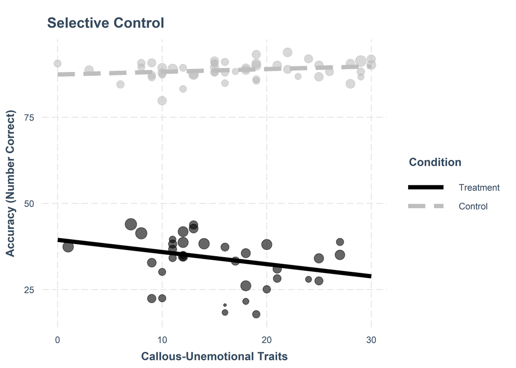

```r
cm6_plot_mod <- lm(ssst_correct_stop ~
           sdq_cd +
           cu_total_sum +
           group_di +
           sex_male +
           iq +
           careless +
           sdq_hyperactivity +
           sdq_internalizing +
           cu_total_sum*sdq_cd +
           group_di*sdq_cd  +
           group_di*cu_total_sum  +
           group_di*cu_total_sum*sdq_cd , weights = ssst_sample_entropy_stop,
         data = dat_sssst
)

cm6_plot <- interactions::interact_plot(cm6_plot_mod,
                            pred = cu_total_sum,
                            modx = group_di,
                            plot.points = TRUE,
                            point.size = TRUE,
                            y.label = "Accuracy (Number Correct)",
                            x.label = "Callous-Unemotional Traits",
                            modx.labels = c("Control","Treatment"),
                            legend.main = "Condition",
                            line.thickness = 2,
                            partial.residuals = TRUE,
                            colors = c("grey","black"))
cm6_plot_edit <- cm6_plot + labs(title = "Selective Control") +
  theme(
    plot.title = element_text(size = 10,
                            hjust = 0.5,
                            face="bold"
                            ),
    legend.position = "none"
    )

ggsave(
  paste0(base_fig,"\\acc_stop_cond_cu.tiff"),
  plot = cm6_plot_edit,
  device = "tiff",
  scale = 1,
  width = 3.5,
  height = 3,
  units = "in",
  dpi = 300
)

ggsave(
  paste0(base_fig,"\\acc_stop_cond_cu_legend.tiff"),
  plot = cm6_plot,
  device = "tiff",
  scale = 1,
  width = 5,
  height = 3,
  units = "in",
  dpi = 300
)

cm6_plot + labs(title = "Selective Control")
```

#### 5.1.4.4 Intercept/Slope by Condition

```r
cm6_plot_vals <- interactions::sim_slopes(cm6_plot_mod, centered = "careless", pred = cu_total_sum, modx = group_di)
```

##### 5.1.4.4.1 Intercepts

```r
(cm6_cond_intercepts <- cm6_plot_vals$int[,c(1:3,6:7,4:5)])
```

| Value of group_di | Est. | S.E. | t val. | p | 2.5% | 97.5% |
| --- | --- | --- | --- | --- | --- | --- |
| 0 | 82.61966 | 4.271645 | 19.341416 | 3.116113e-30 | 74.10429 | 91.13502 |
| 1 | 32.41926 | 5.453605 | 5.944557 | 9.091900e-08 | 21.54770 | 43.29083 |

```r
write.csv(
  cm6_cond_intercepts,
  paste0(base,"\\acc_stop_cond_intercept_results.csv"),
  row.names=TRUE
  )
```

##### 5.1.4.4.2 Slopes

```r
(cm6_cond_slopes <- cm6_plot_vals$slopes[,c(1:3,6:7,4:5)])
```

| Value of group_di | Est. | S.E. | t val. | p | 2.5% | 97.5% |
| --- | --- | --- | --- | --- | --- | --- |
| 0 | -0.006217433 | 0.1732758 | -0.03588171 | 0.97147598 | -0.3516365 | 0.339201605 |
| 1 | -0.518305772 | 0.2591610 | -1.99993743 | 0.04928007 | -1.0349338 | -0.001677772 |

```r
write.csv(
  cm6_cond_slopes,
  paste0(base,"\\acc_stop_cond_slope_results.csv"),
  row.names=TRUE
  )
```

## 5.2 Accuracy (Acc) Contrasts

### 5.2.1 ACC: Selective Control > Go ~

#### 5.2.1.1 Contrast calculation

```r
dat_sssst$contrast_acc_stop_go <- (
  (
    dat_sssst$ssst_correct_stop -
      dat_sssst$ssst_correct_go
    )
  /
    (
      (
        dat_sssst$ssst_correct_stop +
          dat_sssst$ssst_correct_go
        )/2
      )
  )
```

#### 5.2.1.2 Model

```r
cct1 <- lm(contrast_acc_stop_go ~
           sdq_cd +
           cu_total_mean +
           group_di +
           sex_male +
           iq +
           careless +
           sdq_hyperactivity +
           sdq_internalizing +
           int_cucd +
           int_cutest +
           int_cdtest +
           int_cucdtest ,
         data = dat_sssst
)
```

#### 5.2.1.3 Bootstrapped results

|  | Estimate | Std. Error | t value | Pr(>\|t\|) | 2.5% | 97.5% | boot_p | boot_t |
| --- | --- | --- | --- | --- | --- | --- | --- | --- |
| (Intercept) | -1.108 | 0.095 | -11.686 | 0.000 | -1.216 | -0.921 | 0.000 | -4.086 |
| sdq_cd | -0.013 | 0.012 | -1.068 | 0.289 | -0.033 | -0.004 | 0.066 | -1.863 |
| cu_total_mean | -0.002 | 0.060 | -0.032 | 0.975 | -0.043 | 0.069 | 0.944 | -0.070 |
| group_di | -0.412 | 0.032 | -12.936 | 0.000 | -0.472 | -0.395 | 0.000 | -4.086 |
| sex_male | -0.006 | 0.033 | -0.171 | 0.865 | -0.044 | 0.021 | 0.721 | -0.358 |
| iq | 0.001 | 0.001 | 1.441 | 0.154 | -0.001 | 0.002 | 0.079 | 1.778 |
| careless | -0.019 | 0.040 | -0.468 | 0.641 | -0.051 | 0.031 | 0.336 | -0.968 |
| sdq_hyperactivity | -0.001 | 0.008 | -0.151 | 0.880 | -0.003 | 0.012 | 0.757 | -0.310 |
| sdq_internalizing | 0.003 | 0.005 | 0.617 | 0.539 | -0.002 | 0.010 | 0.255 | 1.146 |
| int_cucd | 0.001 | 0.044 | 0.030 | 0.976 | -0.011 | 0.036 | 0.901 | 0.125 |

[output cut: 4 more lines]

#### 5.2.1.4 Figure

- Not significant so none needed

#### 5.2.1.5 Intercept/Slope by Condition

- Not significant so none needed

### 5.2.2 ACC: Passive Control > Go

```r
dat_sssst$contrast_acc_ignore_go <- (
  (
    dat_sssst$ssst_correct_ignore -
      dat_sssst$ssst_correct_go
    )
  /
    (
      (
        dat_sssst$ssst_correct_ignore +
          dat_sssst$ssst_correct_go
        )/2
      )
  )
```

```r
cct2 <- lm(contrast_acc_ignore_go ~
           sdq_cd +
           cu_total_mean +
           group_di +
           sex_male +
           iq +
           careless +
           sdq_hyperactivity +
           sdq_internalizing +
           int_cucd +
           int_cutest +
           int_cdtest +
           int_cucdtest ,
         data = dat_sssst
)
```

#### 5.2.2.1 Bootstrapped results

```r
model <- cct2
  ## extracting values
cont_acc_ignore_go_coef <- coef(summary(model))
r2.adj_cont_acc_ignore_go <- (1-((1-summary(model)$adj.r.squared)*(85-1)/(85-12-1)))

# bootstrapping
set.seed(1979)
aa<-simpleboot::lm.boot(model, R=1000, weights = runif(nrow(model.frame(model))))
cont_acc_ignore_go_boot <- t(simpleboot::perc.lm(aa, p=c(0.025, 0.975)))

  ## adding bootstrapped ci to coefficients
cont_acc_ignore_go_result <- cbind(cont_acc_ignore_go_coef, cont_acc_ignore_go_boot)

# Calculating bootstrap corrected p values
  # extracting bootstrapped values
p_v <- list()
ind <- 1
for(i in aa$boot.list){
  p_v[[ind]] <- ((as.data.frame(i$coef)[[1]]))
  ind <- ind+1
}
  # un-listing bootstrapped values for comparison
vals <- as.numeric(unlist(p_v))
  # extracting model estimates
obs <- as.data.frame(coef(summary(model)))$Estimate

  # Organizing and scaling bootstrapped values for p value calculation
df <- list()
for(i in seq(1,length(vals), by= length(model$coefficients))){
  chunk <- (vals[i:(i+length(model$coefficients)-1)])
  chunk_df <- as.data.frame(t(chunk))
  df <- rbind(df,chunk_df)
}
  # calculating bootstrap corrected p values
p_value <- sapply(1:length(obs), function(i) {
  mean(abs(scale(df[, i], scale=FALSE)) >= abs(obs[i]))
})

p_values <- data.frame(boot_p = p_value)
  # binding boot p values
cont_acc_ignore_go_result <- cbind(cont_acc_ignore_go_result,p_values)


# calculating bootstrap corrected t values
t_value <- list()
for(ii in p_value){
  if(ii > 0){
    t_value <- append(t_value,qt(ii/2, 85-1, lower.tail = FALSE))
  } else{
    t_value <- append(t_value,qt(0.0001/2, 85-1, lower.tail = FALSE))
  }
}

for(ii in 1:length(t_value)){
  if(obs[ii] < 0)(
    t_value[[ii]] <- (-1)*t_value[[ii]]
  )
}

t_values <- data.frame(boot_t = unlist(t_value))

  # binding boot t values
cont_acc_ignore_go_result <- cbind(cont_acc_ignore_go_result,t_values)

  # binding r2
r2 <- t(as.data.frame((c(r2.adj_cont_acc_ignore_go,NA,NA,NA,NA,NA,NA, NA))))
rownames(r2) <- "Adj.R2"
colnames(r2) <- colnames(cont_acc_ignore_go_result)
round(cont_acc_ignore_go_result <- rbind(cont_acc_ignore_go_result,r2), 3)
```

|  | Estimate | Std. Error | t value | Pr(>\|t\|) | 2.5% | 97.5% | boot_p | boot_t |
| --- | --- | --- | --- | --- | --- | --- | --- | --- |
| (Intercept) | -1.238 | 0.133 | -9.335 | 0.000 | -1.678 | -1.002 | 0.000 | -4.086 |
| sdq_cd | -0.055 | 0.017 | -3.209 | 0.002 | -0.102 | -0.041 | 0.001 | -3.410 |
| cu_total_mean | 0.138 | 0.084 | 1.636 | 0.106 | 0.097 | 0.338 | 0.034 | 2.155 |
| group_di | -0.187 | 0.045 | -4.202 | 0.000 | -0.290 | -0.148 | 0.000 | -4.086 |
| sex_male | 0.035 | 0.046 | 0.766 | 0.446 | -0.012 | 0.137 | 0.342 | 0.956 |
| iq | 0.002 | 0.001 | 1.514 | 0.134 | -0.001 | 0.005 | 0.232 | 1.204 |
| careless | -0.064 | 0.056 | -1.141 | 0.258 | -0.076 | 0.126 | 0.195 | -1.306 |
| sdq_hyperactivity | -0.004 | 0.011 | -0.403 | 0.688 | -0.016 | 0.013 | 0.567 | -0.575 |
| sdq_internalizing | 0.010 | 0.007 | 1.311 | 0.194 | -0.002 | 0.025 | 0.155 | 1.435 |
| int_cucd | -0.006 | 0.062 | -0.091 | 0.928 | -0.051 | 0.069 | 0.829 | -0.217 |

[output cut: 4 more lines]

```r
# saving results to csv
write.csv(
  cont_acc_ignore_go_result,
  paste0(base,"\\acc_contrast_ignore_go_results.csv"),
  row.names=TRUE
  )
```

#### 5.2.2.2 Figure

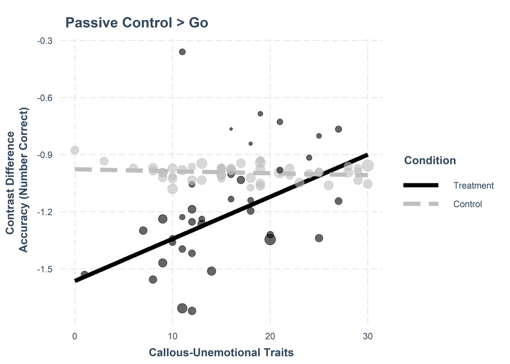

```r
cct2_plot_mod <- lm(contrast_acc_ignore_go ~
           sdq_cd +
           cu_total_sum +
           group_di +
           sex_male +
           iq +
           careless +
           sdq_hyperactivity +
           sdq_internalizing +
           cu_total_sum*sdq_cd +
           group_di*sdq_cd  +
           group_di*cu_total_sum  +
           group_di*cu_total_sum*sdq_cd , weights = ssst_sample_entropy_ignore,
         data = dat_sssst
)

cct2_plot <- interactions::interact_plot(cct2_plot_mod,
                            pred = cu_total_sum,
                            modx = group_di,
                            plot.points = TRUE,
                            point.size = TRUE,
                            y.label = "Contrast Difference \n Accuracy (Number Correct)",
                            x.label = "Callous-Unemotional Traits",
                            modx.labels = c("Control","Treatment"),
                            legend.main = "Condition",
                            line.thickness = 2,
                            partial.residuals = TRUE,
                            colors = c("grey","black"))
cct2_plot_edit <- cct2_plot + labs(title = "Passive Control > Go") +
  theme(
    plot.title = element_text(size = 10,
                            hjust = 0.5,
                            face="bold"
                            ),
    legend.position = "none"
    )

ggsave(
  paste0(base_fig,"\\acc_contrast_ignore_go_cond_cu.tiff"),
  plot = cct2_plot_edit,
  device = "tiff",
  scale = 1,
  width = 3.5,
  height = 3,
  units = "in",
  dpi = 300
)

ggsave(
  paste0(base_fig,"\\acc_contrast_ignore_go_cond_cu_legend.tiff"),
  plot = cct2_plot,
  device = "tiff",
  scale = 1,
  width = 5,
  height = 3,
  units = "in",
  dpi = 300
)

cct2_plot + labs(title = "Passive Control > Go")
```

#### 5.2.2.3 Intercept/Slope by Condition

```r
cct2_plot_vals <- interactions::sim_slopes(cct2_plot_mod, pred = cu_total_sum, modx = group_di)
```

##### 5.2.2.3.1 Intercepts

```r
(cct2_cond_intercepts <- cct2_plot_vals$int[,c(1:3,6:7,4:5)])
```

| Value of group_di | Est. | S.E. | t val. | p | 2.5% | 97.5% |
| --- | --- | --- | --- | --- | --- | --- |
| 0 | -0.9632797 | 0.08473133 | -11.36864 | 9.874286e-18 | -1.132188 | -0.7943708 |
| 1 | -1.5218713 | 0.10830946 | -14.05114 | 2.539911e-22 | -1.737782 | -1.3059604 |

```r
write.csv(
  cct2_cond_intercepts,
  paste0(base,"\\acc_contrast_ignore_go_cond_intercept_results.csv"),
  row.names=TRUE
  )
```

##### 5.2.2.3.2 Slopes

```r
(cct2_cond_slopes <- cct2_plot_vals$slopes[,c(1:3,6:7,4:5)])
```

| Value of group_di | Est. | S.E. | t val. | p | 2.5% | 97.5% |
| --- | --- | --- | --- | --- | --- | --- |
| 0 | -0.001709037 | 0.004418810 | -0.3867641 | 0.70007162 | -0.01051777 | 0.00709970 |
| 1 | 0.022684839 | 0.006778272 | 3.3466993 | 0.00130247 | 0.00917260 | 0.03619708 |

```r
write.csv(
  cct2_cond_slopes,
  paste0(base,"\\acc_contrast_ignore_go_cond_slope_results.csv"),
  row.names=TRUE
  )
```

### 5.2.3 ACC: Selective > Passive Control

```r
dat_sssst$contrast_acc_stop_ignore <- (
  (
    dat_sssst$ssst_correct_stop -
      dat_sssst$ssst_correct_ignore
    )
  /
    (
      (
        dat_sssst$ssst_correct_stop +
          dat_sssst$ssst_correct_ignore
        )/2
      )
  )
```

```r
cct3 <- lm(contrast_acc_stop_ignore ~
           sdq_cd +
           cu_total_mean +
           group_di +
           sex_male +
           iq +
           careless +
           sdq_hyperactivity +
           sdq_internalizing +
           int_cucd +
           int_cutest +
           int_cdtest +
           int_cucdtest ,
         data = dat_sssst
)
```

#### 5.2.3.1 Bootstrapped results

|  | Estimate | Std. Error | t value | Pr(>\|t\|) | 2.5% | 97.5% | boot_p | boot_t |
| --- | --- | --- | --- | --- | --- | --- | --- | --- |
| (Intercept) | 0.213 | 0.220 | 0.971 | 0.335 | -0.015 | 1.079 | 0.213 | 1.256 |
| sdq_cd | 0.079 | 0.028 | 2.764 | 0.007 | 0.030 | 0.141 | 0.000 | 3.896 |
| cu_total_mean | -0.197 | 0.139 | -1.410 | 0.163 | -0.538 | -0.137 | 0.003 | -3.104 |
| group_di | -0.317 | 0.074 | -4.301 | 0.000 | -0.435 | -0.166 | 0.000 | -4.086 |
| sex_male | -0.061 | 0.076 | -0.795 | 0.429 | -0.253 | 0.008 | 0.123 | -1.557 |
| iq | -0.001 | 0.002 | -0.560 | 0.577 | -0.009 | 0.002 | 0.432 | -0.790 |
| careless | 0.074 | 0.093 | 0.797 | 0.428 | -0.243 | 0.101 | 0.135 | 1.510 |
| sdq_hyperactivity | -0.001 | 0.018 | -0.044 | 0.965 | -0.023 | 0.032 | 0.929 | -0.089 |
| sdq_internalizing | -0.011 | 0.012 | -0.929 | 0.356 | -0.034 | 0.007 | 0.068 | -1.852 |
| int_cucd | 0.006 | 0.103 | 0.061 | 0.951 | -0.105 | 0.091 | 0.780 | 0.281 |

[output cut: 4 more lines]

#### 5.2.3.2 Figure

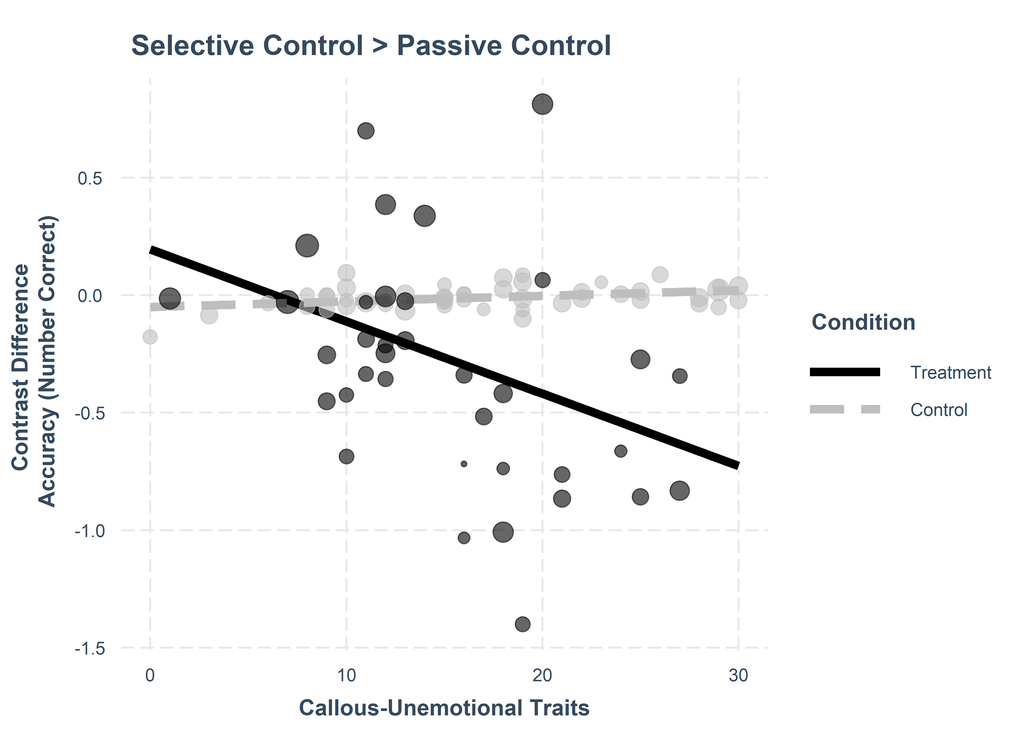

```r
cct3_plot_mod <- lm(contrast_acc_stop_ignore ~
           sdq_cd +
           cu_total_sum +
           group_di +
           sex_male +
           iq +
           careless +
           sdq_hyperactivity +
           sdq_internalizing +
           cu_total_sum*sdq_cd +
           group_di*sdq_cd  +
           group_di*cu_total_sum  +
           group_di*cu_total_sum*sdq_cd,
           weights = ssst_sample_entropy_stop,
         data = dat_sssst
)

cc3_plot <- interactions::interact_plot(cct3_plot_mod,
                            pred = cu_total_sum,
                            modx = group_di,
                            plot.points = TRUE,
                            point.size = TRUE,
                            y.label = "Contrast Difference \n Accuracy (Number Correct)",
                            x.label = "Callous-Unemotional Traits",
                            modx.labels = c("Control","Treatment"),
                            legend.main = "Condition",
                            line.thickness = 2,
                            partial.residuals = TRUE,
                            colors = c("grey","black"))
cc3_plot_edit <- cc3_plot + labs(title = "Selective Control > Passive Control") +
  theme(
    plot.title = element_text(size = 10,
                            hjust = 0.5,
                            face="bold"
                            ),
    legend.position = "none"
    )

ggsave(
  paste0(base_fig,"\\acc_contrast_stop_ignore_cond_cu.tiff"),
  plot = cc3_plot_edit,
  device = "tiff",
  scale = 1,
  width = 3.5,
  height = 3,
  units = "in",
  dpi = 300
)

ggsave(
  paste0(base_fig,"\\acc_contrast_stop_ignore_cond_cu_legend.tiff"),
  plot = cc3_plot,
  device = "tiff",
  scale = 1,
  width = 5,
  height = 3,
  units = "in",
  dpi = 300
)

cc3_plot + labs(title = "Selective Control > Passive Control")
```

#### 5.2.3.3 Intercept/Slope by Condition

```r
cc3_plot_vals <- interactions::sim_slopes(cct3_plot_mod, pred = cu_total_sum, modx = group_di)
```

##### 5.2.3.3.1 Intercepts

```r
(cc3_cond_intercepts <- cc3_plot_vals$int[,c(1:3,6:7,4:5)])
```

| Value of group_di | Est. | S.E. | t val. | p | 2.5% | 97.5% |
| --- | --- | --- | --- | --- | --- | --- |
| 0 | -0.0666067 | 0.1415654 | -0.4705014 | 0.6394191 | -0.3488121 | 0.2155987 |
| 1 | 0.1736950 | 0.1805352 | 0.9621115 | 0.3392137 | -0.1861954 | 0.5335854 |

```r
write.csv(
  cc3_cond_intercepts,
  paste0(base,"\\acc_contrast_stop_ignore_cond_intercept_results.csv"),
  row.names=TRUE
  )
```

##### 5.2.3.3.2 Slopes

```r
(cc3_cond_slopes <- cc3_plot_vals$slopes[,c(1:3,6:7,4:5)])
```

| Value of group_di | Est. | S.E. | t val. | p | 2.5% | 97.5% |
| --- | --- | --- | --- | --- | --- | --- |
| 0 | 0.003094061 | 0.007323858 | 0.4224633 | 0.673945870 | -0.01150578 | 0.01769390 |
| 1 | -0.033607789 | 0.011225366 | -2.9939147 | 0.003772781 | -0.05598515 | -0.01123043 |

```r
write.csv(
  cc3_cond_slopes,
  paste0(base,"\\acc_contrast_stop_ignore_cond_slope_results.csv"),
  row.names=TRUE
  )
```

# 6 Tertiary analyses

## 6.1 Sample entropy

### 6.1.1 Sample entropy: Overall ~

#### 6.1.1.1 Model

```r
ent1 <- lm(ssst_sample_entropy_all ~
             sdq_cd +
             cu_total_mean +
             group_di +
             sex_male +
             iq +
             careless +
             sdq_hyperactivity +
             sdq_internalizing +
             int_cucd +
             int_cutest +
             int_cdtest +
             int_cucdtest,
           data = dat_sssst
)
```

#### 6.1.1.2 Bootstrapped results

|  | Estimate | Std. Error | t value | Pr(>\|t\|) | 2.5% | 97.5% | boot_p | boot_t |
| --- | --- | --- | --- | --- | --- | --- | --- | --- |
| (Intercept) | 1.513 | 0.178 | 8.511 | 0.000 | 1.058 | 1.873 | 0.000 | 4.086 |
| sdq_cd | 0.002 | 0.023 | 0.072 | 0.943 | -0.036 | 0.067 | 0.960 | 0.050 |
| cu_total_mean | -0.181 | 0.113 | -1.606 | 0.113 | -0.288 | 0.292 | 0.221 | -1.233 |
| group_di | 0.093 | 0.060 | 1.557 | 0.124 | 0.007 | 0.273 | 0.174 | 1.371 |
| sex_male | -0.006 | 0.062 | -0.094 | 0.926 | -0.182 | 0.033 | 0.924 | -0.096 |
| iq | -0.002 | 0.002 | -0.939 | 0.351 | -0.006 | 0.003 | 0.449 | -0.761 |
| careless | 0.170 | 0.075 | 2.260 | 0.027 | -0.031 | 0.322 | 0.064 | 1.877 |
| sdq_hyperactivity | 0.018 | 0.014 | 1.273 | 0.207 | -0.021 | 0.042 | 0.252 | 1.153 |
| sdq_internalizing | 0.002 | 0.010 | 0.235 | 0.815 | -0.034 | 0.007 | 0.808 | 0.244 |
| int_cucd | 0.027 | 0.083 | 0.327 | 0.745 | -0.105 | 0.228 | 0.725 | 0.353 |

[output cut: 4 more lines]

#### 6.1.1.3 Figure

- Not significant so none needed

#### 6.1.1.4 Intercept/Slope by Condition

- Not significant so none needed

### 6.1.2 Sample Entropy: go ~

#### 6.1.2.1 Model

```r
ent2 <- lm(ssst_sample_entropy_go ~
           sdq_cd +
           cu_total_mean +
           group_di +
           sex_male +
           iq +
           careless +
           sdq_hyperactivity +
           sdq_internalizing +
           int_cucd +
           int_cutest +
           int_cdtest +
           int_cucdtest ,
         data = dat_sssst
)
```

#### 6.1.2.2 Bootstrapped results

|  | Estimate | Std. Error | t value | Pr(>\|t\|) | 2.5% | 97.5% | boot_p | boot_t |
| --- | --- | --- | --- | --- | --- | --- | --- | --- |
| (Intercept) | 1.511 | 0.222 | 6.808 | 0.000 | 0.784 | 2.057 | 0.000 | 4.086 |
| sdq_cd | -0.010 | 0.029 | -0.357 | 0.722 | -0.083 | 0.036 | 0.710 | -0.373 |
| cu_total_mean | -0.147 | 0.141 | -1.041 | 0.302 | -0.563 | 0.093 | 0.348 | -0.944 |
| group_di | 0.106 | 0.075 | 1.424 | 0.159 | -0.145 | 0.171 | 0.168 | 1.391 |
| sex_male | 0.023 | 0.077 | 0.297 | 0.767 | -0.140 | 0.154 | 0.741 | 0.332 |
| iq | -0.002 | 0.002 | -0.740 | 0.462 | -0.007 | 0.006 | 0.559 | -0.587 |
| careless | 0.216 | 0.094 | 2.304 | 0.024 | 0.039 | 0.499 | 0.059 | 1.914 |
| sdq_hyperactivity | 0.023 | 0.018 | 1.291 | 0.201 | 0.013 | 0.090 | 0.230 | 1.209 |
| sdq_internalizing | 0.002 | 0.012 | 0.155 | 0.877 | -0.039 | 0.029 | 0.906 | 0.118 |
| int_cucd | 0.034 | 0.104 | 0.324 | 0.747 | -0.143 | 0.198 | 0.659 | 0.443 |

[output cut: 4 more lines]

#### 6.1.2.3 Figure

- Not significant so none needed

#### 6.1.2.4 Intercept/Slope by Condition

- Not significant so none needed

### 6.1.3 Sample entropy: Passive Control ~

#### 6.1.3.1 Model

```r
ent3 <- lm(ssst_sample_entropy_ignore ~
           sdq_cd +
           cu_total_mean +
           group_di +
           sex_male +
           iq +
           careless +
           sdq_hyperactivity +
           sdq_internalizing +
           int_cucd +
           int_cutest +
           int_cdtest +
           int_cucdtest,
         data = dat_sssst
)
```

#### 6.1.3.2 Bootstrapped results

```r
model <- ent3
  ## extracting values
ent_ignore_coef <- coef(summary(model))
r2.adj_ent_ignore <- (1-((1-summary(model)$r.squared)*(85-1)/(85-12-1)))

# bootstrapping
set.seed(1835)
aa<-simpleboot::lm.boot(model, R=1000, weights = runif(nrow(model.frame(model))))
ent_ignore_boot <- t(simpleboot::perc.lm(aa, p=c(0.025, 0.975)))

  ## adding bootstrapped ci to coefficient_ignores
ent_ignore_result <- cbind(ent_ignore_coef, ent_ignore_boot)

# Calculating bootstrap corrected p values
  # extracting bootstrapped values
p_v <- list()
ind <- 1
for(i in aa$boot.list){
  p_v[[ind]] <- ((as.data.frame(i$coef)[[1]]))
  ind <- ind+1
}
  # un-listing bootstrapped values for comparison
vals <- as.numeric(unlist(p_v))
  # extracting model estimates
obs <- as.data.frame(coef(summary(model)))$Estimate

  # Organizing and scaling bootstrapped values for p value calculation
df <- list()
for(i in seq(1,length(vals), by= length(model$coefficients))){
  chunk <- (vals[i:(i+length(model$coefficients)-1)])
  chunk_df <- as.data.frame(t(chunk))
  df <- rbind(df,chunk_df)
}
  # calculating bootstrap corrected p values
p_value <- sapply(1:length(obs), function(i) {
  mean(abs(scale(df[, i], scale=FALSE)) >= abs(obs[i]))
})

p_values <- data.frame(boot_p = p_value)
  # binding boot p values
ent_ignore_result <- cbind(ent_ignore_result,p_values)


# calculating bootstrap corrected t values
t_value <- list()
for(ii in p_value){
  if(ii > 0){
    t_value <- append(t_value,qt(ii/2, 85-1, lower.tail = FALSE))
  } else{
    t_value <- append(t_value,qt(0.0001/2, 85-1, lower.tail = FALSE))
  }
}

for(ii in 1:length(t_value)){
  if(obs[ii] < 0)(
    t_value[[ii]] <- (-1)*t_value[[ii]]
  )
}

t_values <- data.frame(boot_t = unlist(t_value))

  # binding boot t values
ent_ignore_result <- cbind(ent_ignore_result,t_values)


  # binding r2
r2 <- t(as.data.frame((c(r2.adj_ent_ignore,NA,NA,NA,NA,NA,NA, NA))))
rownames(r2) <- "Adj.R2"
colnames(r2) <- colnames(ent_ignore_result)
round(ent_ignore_result <- rbind(ent_ignore_result,r2), 3)
```

|  | Estimate | Std. Error | t value | Pr(>\|t\|) | 2.5% | 97.5% | boot_p | boot_t |
| --- | --- | --- | --- | --- | --- | --- | --- | --- |
| (Intercept) | 1.653 | 0.241 | 6.873 | 0.000 | 1.274 | 2.543 | 0.000 | 4.086 |
| sdq_cd | 0.015 | 0.031 | 0.491 | 0.625 | -0.058 | 0.120 | 0.749 | 0.321 |
| cu_total_mean | -0.103 | 0.153 | -0.672 | 0.504 | -0.362 | 0.262 | 0.493 | -0.689 |
| group_di | -0.470 | 0.081 | -5.813 | 0.000 | -0.615 | -0.260 | 0.000 | -4.086 |
| sex_male | -0.018 | 0.084 | -0.221 | 0.826 | -0.184 | 0.127 | 0.837 | -0.206 |
| iq | -0.003 | 0.002 | -1.140 | 0.258 | -0.012 | 0.001 | 0.427 | -0.798 |
| careless | 0.084 | 0.102 | 0.826 | 0.412 | -0.171 | 0.440 | 0.553 | 0.596 |
| sdq_hyperactivity | 0.019 | 0.019 | 0.979 | 0.331 | -0.017 | 0.064 | 0.340 | 0.960 |
| sdq_internalizing | -0.005 | 0.013 | -0.347 | 0.729 | -0.045 | 0.013 | 0.748 | -0.322 |
| int_cucd | -0.103 | 0.112 | -0.913 | 0.364 | -0.376 | 0.133 | 0.355 | -0.930 |

[output cut: 4 more lines]

```r
# saving results to csv
write.csv(
  ent_ignore_result,
  paste0(base,"\\ent_ignore_results.csv"),
  row.names=TRUE
  )
```

#### 6.1.3.3 Figure

- Not significant so none needed

#### 6.1.3.4 Intercept/Slope by Condition

- Not significant so none needed

### 6.1.4 Sample entropy: Selective Control ~

#### 6.1.4.1 Model

```r
ent4 <- lm(ssst_sample_entropy_stop ~
           sdq_cd +
           cu_total_mean +
           group_di +
           sex_male +
           iq +
           careless +
           sdq_hyperactivity +
           sdq_internalizing +
           int_cucd +
           int_cutest +
           int_cdtest +
           int_cucdtest,
         data = dat_sssst
)
```

#### 6.1.4.2 Bootstrapped results

```r
model <- ent4
  ## extracting values
ent_stop_coef <- coef(summary(model))
r2.adj_ent_stop <- (1-((1-summary(model)$r.squared)*(85-1)/(85-12-1)))

# bootstrapping
set.seed(1979)
aa<-simpleboot::lm.boot(model, R=1000, weights = runif(nrow(model.frame(model))))
ent_stop_boot <- t(simpleboot::perc.lm(aa, p=c(0.025, 0.975)))

  ## adding bootstrapped ci to coefficient_stops
ent_stop_result <- cbind(ent_stop_coef, ent_stop_boot)

# Calculating bootstrap corrected p values
  # extracting bootstrapped values
p_v <- list()
ind <- 1
for(i in aa$boot.list){
  p_v[[ind]] <- ((as.data.frame(i$coef)[[1]]))
  ind <- ind+1
}
  # un-listing bootstrapped values for comparison
vals <- as.numeric(unlist(p_v))
  # extracting model estimates
obs <- as.data.frame(coef(summary(model)))$Estimate

  # Organizing and scaling bootstrapped values for p value calculation
df <- list()
for(i in seq(1,length(vals), by= length(model$coefficients))){
  chunk <- (vals[i:(i+length(model$coefficients)-1)])
  chunk_df <- as.data.frame(t(chunk))
  df <- rbind(df,chunk_df)
}
  # calculating bootstrap corrected p values
p_value <- sapply(1:length(obs), function(i) {
  mean(abs(scale(df[, i], scale=FALSE)) >= abs(obs[i]))
})

p_values <- data.frame(boot_p = p_value)
  # binding boot p values
ent_stop_result <- cbind(ent_stop_result,p_values)

# calculating bootstrap corrected t values
t_value <- list()
for(ii in p_value){
  if(ii > 0){
    t_value <- append(t_value,qt(ii/2, 85-1, lower.tail = FALSE))
  } else{
    t_value <- append(t_value,qt(0.0001/2, 85-1, lower.tail = FALSE))
  }
}

for(ii in 1:length(t_value)){
  if(obs[ii] < 0)(
    t_value[[ii]] <- (-1)*t_value[[ii]]
  )
}

t_values <- data.frame(boot_t = unlist(t_value))

  # binding boot t values
ent_stop_result <- cbind(ent_stop_result,t_values)



  # binding r2
r2 <- t(as.data.frame((c(r2.adj_ent_stop,NA,NA,NA,NA,NA,NA, NA))))
rownames(r2) <- "Adj.R2"
colnames(r2) <- colnames(ent_stop_result)
round(ent_stop_result <- rbind(ent_stop_result,r2), 3)
```

|  | Estimate | Std. Error | t value | Pr(>\|t\|) | 2.5% | 97.5% | boot_p | boot_t |
| --- | --- | --- | --- | --- | --- | --- | --- | --- |
| (Intercept) | 1.448 | 0.260 | 5.564 | 0.000 | 1.080 | 2.157 | 0.000 | 4.086 |
| sdq_cd | 0.052 | 0.034 | 1.542 | 0.127 | 0.000 | 0.165 | 0.181 | 1.349 |
| cu_total_mean | -0.170 | 0.165 | -1.028 | 0.307 | -0.463 | 0.144 | 0.258 | -1.139 |
| group_di | 0.121 | 0.087 | 1.382 | 0.171 | -0.085 | 0.270 | 0.180 | 1.352 |
| sex_male | 0.036 | 0.090 | 0.398 | 0.692 | -0.133 | 0.219 | 0.685 | 0.407 |
| iq | -0.001 | 0.003 | -0.275 | 0.784 | -0.009 | 0.003 | 0.797 | -0.258 |
| careless | 0.248 | 0.110 | 2.252 | 0.027 | -0.087 | 0.383 | 0.038 | 2.108 |
| sdq_hyperactivity | -0.003 | 0.021 | -0.144 | 0.886 | -0.053 | 0.034 | 0.883 | -0.148 |
| sdq_internalizing | -0.001 | 0.015 | -0.065 | 0.948 | -0.024 | 0.040 | 0.957 | -0.054 |
| int_cucd | -0.066 | 0.122 | -0.539 | 0.591 | -0.235 | 0.124 | 0.459 | -0.744 |

[output cut: 4 more lines]

```r
# saving results to csv
write.csv(
  ent_stop_result,
  paste0(base,"\\ent_stop_results.csv"),
  row.names=TRUE
  )
```

#### 6.1.4.3 Figure

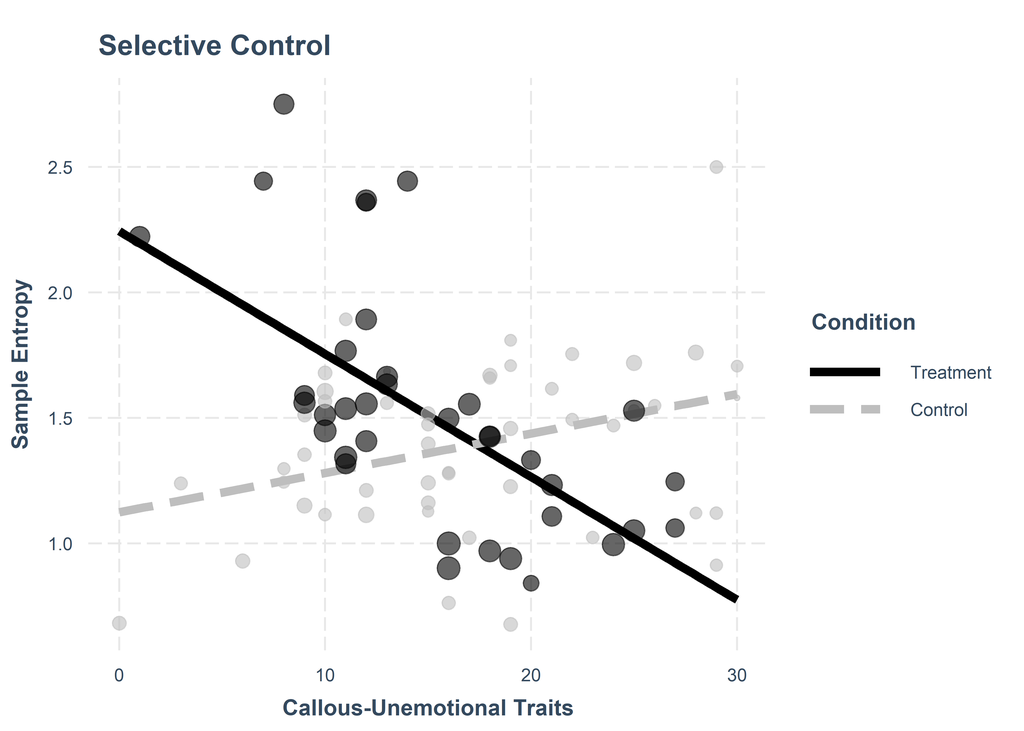

```r
ent4_plot_mod <- lm(ssst_sample_entropy_stop ~
           sdq_cd +
           cu_total_sum +
           group_di +
           sex_male +
           iq +
           careless +
           sdq_hyperactivity +
           sdq_internalizing +
           cu_total_sum*sdq_cd +
           group_di*sdq_cd  +
           group_di*cu_total_sum  +
           group_di*cu_total_sum*sdq_cd , weights = ssst_mean_rt_stop,
         data = dat_sssst
)

ent4_plot <- interactions::interact_plot(ent4_plot_mod,
                            pred = cu_total_sum,
                            modx = group_di,
                            plot.points = TRUE,
                            point.size = TRUE,
                            y.label = "Sample Entropy",
                            x.label = "Callous-Unemotional Traits",
                            modx.labels = c("Control","Treatment"),
                            legend.main = "Condition",
                            line.thickness = 2,
                            partial.residuals = TRUE,
                            colors = c("grey","black"))
ent4_plot_edit <- ent4_plot + labs(title = "Selective Control") +
  theme(
    plot.title = element_text(size = 10,
                            hjust = 0.5,
                            face="bold"
                            ),
    legend.position = "none"
    )

ggsave(
  paste0(base_fig,"\\ent_stop_cond_cu.tiff"),
  plot = ent4_plot_edit,
  device = "tiff",
  scale = 1,
  width = 3.5,
  height = 3,
  units = "in",
  dpi = 300
)

ggsave(
  paste0(base_fig,"\\ent_stop_cond_cu_legend.tiff"),
  plot = ent4_plot,
  device = "tiff",
  scale = 1,
  width = 5,
  height = 3,
  units = "in",
  dpi = 300
)

ent4_plot + labs(title = "Selective Control")
```

#### 6.1.4.4 Intercept/Slope by Condition

```r
ent4_plot_vals <- interactions::sim_slopes(ent4_plot_mod, pred = cu_total_sum, modx = group_di)
```

##### 6.1.4.4.1 Intercepts

```r
(ent4_cond_intercepts <- ent4_plot_vals$int[,c(1:3,6:7,4:5)])
```

| Value of group_di | Est. | S.E. | t val. | p | 2.5% | 97.5% |
| --- | --- | --- | --- | --- | --- | --- |
| 0 | 1.195561 | 0.1655156 | 7.223251 | 4.275475e-10 | 0.8656116 | 1.525510 |
| 1 | 2.257995 | 0.2093495 | 10.785766 | 1.095107e-16 | 1.8406644 | 2.675326 |

```r
write.csv(
  ent4_cond_intercepts,
  paste0(base,"\\ent_stop_cond_intercept_results.csv"),
  row.names=TRUE
  )
```

##### 6.1.4.4.2 Slopes

```r
(ent4_cond_slopes <- ent4_plot_vals$slopes[,c(1:3,6:7,4:5)])
```

| Value of group_di | Est. | S.E. | t val. | p | 2.5% | 97.5% |
| --- | --- | --- | --- | --- | --- | --- |
| 0 | 0.01161869 | 0.008634502 | 1.345612 | 0.182650041 | -0.005593877 | 0.02883125 |
| 1 | -0.04850900 | 0.013287367 | -3.650761 | 0.000492234 | -0.074996882 | -0.02202112 |

```r
write.csv(
  ent4_cond_slopes,
  paste0(base,"\\ent_stop_cond_slope_results.csv"),
  row.names=TRUE
  )
```

## 6.2 Balanced Integration Score (BIS)

- Article: https://psycnet.apa.org/doi/10.3758/s13428-018-1076-x
- Interpretation of this metric is
  - higher = better inhibitory control
  - lower = worse inhibitory control

### 6.2.1 calculating BIS

```r
## Function
BIS <- function(rt_name, acc_name, output_name, data) {
  # Ensure rt_name, acc_name, and output_name are strings
  rt_name <- deparse(substitute(rt_name))
  acc_name <- deparse(substitute(acc_name))
  output_name <- deparse(substitute(output_name))

  # Find indices for the given column names
  rt_ind <- which(colnames(data) == rt_name)
  acc_ind <- which(colnames(data) == acc_name)

  # Ensure the specified column names exist in the dataset
  if (length(rt_ind) == 0 || length(acc_ind) == 0) {
    stop("One or more specified column names do not exist in the dataset.")
  }

  # Scale the selected columns
  z_rt <- scale(data[, rt_ind])
  z_acc <- scale(data[, acc_ind])

  # Compute the BIS
  BIS <- as.array(z_acc - z_rt)[1:NROW(data)]

  return(BIS)
}

## calculating with function
dat_sssst$bis_overall <- BIS(ssst_mean_rt_rc, ssst_correct, overall, dat_sssst)
dat_sssst$bis_go <- BIS(ssst_mean_rt_go, ssst_correct_go, go, dat_sssst)
dat_sssst$bis_passive <- BIS(ssst_mean_rt_ignore_rc, ssst_correct_ignore, passive, dat_sssst)
dat_sssst$bis_selective <- BIS(ssst_mean_rt_stop, ssst_correct_stop, selective, dat_sssst)
```

### 6.2.2 Overall BIS model

```r
mbis_all <- lm(bis_overall ~
             sdq_cd +
             cu_total_mean +
             group_di +
             sex_male +
             iq +
             careless +
             sdq_hyperactivity +
             sdq_internalizing +
             int_cucd +
             int_cutest +
             int_cdtest +
             int_cucdtest,
           data = dat_sssst
)
```

#### 6.2.2.1 Bootstrapped results

|  | Estimate | Std. Error | t value | Pr(>\|t\|) | 2.5% | 97.5% | boot_p | boot_t |
| --- | --- | --- | --- | --- | --- | --- | --- | --- |
| (Intercept) | 0.531 | 0.497 | 1.067 | 0.290 | -0.439 | 2.125 | 0.411 | 0.826 |
| sdq_cd | 0.125 | 0.064 | 1.945 | 0.056 | 0.061 | 0.297 | 0.043 | 2.055 |
| cu_total_mean | 0.037 | 0.316 | 0.119 | 0.906 | -0.434 | 0.725 | 0.892 | 0.136 |
| group_di | -3.705 | 0.167 | -22.170 | 0.000 | -3.866 | -3.364 | 0.000 | -4.086 |
| sex_male | -0.059 | 0.173 | -0.340 | 0.735 | -0.488 | 0.080 | 0.699 | -0.388 |
| iq | 0.008 | 0.005 | 1.582 | 0.118 | -0.007 | 0.019 | 0.249 | 1.161 |
| careless | 0.156 | 0.210 | 0.742 | 0.461 | -0.474 | 0.324 | 0.426 | 0.800 |
| sdq_hyperactivity | 0.002 | 0.040 | 0.038 | 0.970 | -0.089 | 0.019 | 0.947 | 0.067 |
| sdq_internalizing | 0.014 | 0.028 | 0.487 | 0.628 | -0.039 | 0.065 | 0.597 | 0.531 |
| int_cucd | 0.180 | 0.232 | 0.776 | 0.440 | -0.079 | 0.603 | 0.268 | 1.115 |

[output cut: 4 more lines]

### 6.2.3 Go BIS model

```r
mbis_go <- lm(bis_go ~
             sdq_cd +
             cu_total_mean +
             group_di +
             sex_male +
             iq +
             careless +
             sdq_hyperactivity +
             sdq_internalizing +
             int_cucd +
             int_cutest +
             int_cdtest +
             int_cucdtest,
           data = dat_sssst
)
```

#### 6.2.3.1 Bootstrapped results

|  | Estimate | Std. Error | t value | Pr(>\|t\|) | 2.5% | 97.5% | boot_p | boot_t |
| --- | --- | --- | --- | --- | --- | --- | --- | --- |
| (Intercept) | 1.085 | 0.599 | 1.811 | 0.074 | -0.013 | 2.929 | 0.133 | 1.517 |
| sdq_cd | 0.199 | 0.078 | 2.568 | 0.012 | 0.151 | 0.431 | 0.014 | 2.510 |
| cu_total_mean | -0.136 | 0.380 | -0.356 | 0.723 | -0.744 | 0.377 | 0.625 | -0.491 |
| group_di | -3.444 | 0.201 | -17.102 | 0.000 | -3.587 | -3.006 | 0.000 | -4.086 |
| sex_male | -0.108 | 0.208 | -0.520 | 0.605 | -0.601 | 0.033 | 0.509 | -0.663 |
| iq | 0.002 | 0.006 | 0.344 | 0.732 | -0.014 | 0.017 | 0.811 | 0.240 |
| careless | 0.271 | 0.253 | 1.068 | 0.289 | -0.594 | 0.380 | 0.288 | 1.069 |
| sdq_hyperactivity | 0.009 | 0.049 | 0.193 | 0.847 | -0.098 | 0.024 | 0.760 | 0.306 |
| sdq_internalizing | -0.013 | 0.034 | -0.393 | 0.696 | -0.076 | 0.044 | 0.638 | -0.472 |
| int_cucd | 0.192 | 0.280 | 0.685 | 0.495 | -0.127 | 0.570 | 0.264 | 1.125 |

[output cut: 4 more lines]

### 6.2.4 Passive BIS model

```r
mbis_ignore <- lm(bis_passive ~
             sdq_cd +
             cu_total_mean +
             group_di +
             sex_male +
             iq +
             careless +
             sdq_hyperactivity +
             sdq_internalizing +
             int_cucd +
             int_cutest +
             int_cdtest +
             int_cucdtest,
           data = dat_sssst
)
```

#### 6.2.4.1 Bootstrapped results

|  | Estimate | Std. Error | t value | Pr(>\|t\|) | 2.5% | 97.5% | boot_p | boot_t |
| --- | --- | --- | --- | --- | --- | --- | --- | --- |
| (Intercept) | -0.751 | 0.425 | -1.768 | 0.081 | -2.507 | -0.085 | 0.209 | -1.266 |
| sdq_cd | -0.181 | 0.055 | -3.287 | 0.002 | -0.380 | -0.072 | 0.026 | -2.266 |
| cu_total_mean | 0.281 | 0.270 | 1.044 | 0.300 | 0.097 | 1.029 | 0.182 | 1.346 |
| group_di | 0.049 | 0.143 | 0.346 | 0.730 | -0.265 | 0.343 | 0.740 | 0.333 |
| sex_male | 0.173 | 0.148 | 1.169 | 0.246 | -0.035 | 0.507 | 0.207 | 1.272 |
| iq | 0.005 | 0.004 | 1.250 | 0.215 | -0.004 | 0.021 | 0.385 | 0.873 |
| careless | -0.069 | 0.179 | -0.383 | 0.703 | -0.140 | 0.606 | 0.714 | -0.368 |
| sdq_hyperactivity | 0.012 | 0.034 | 0.339 | 0.736 | -0.049 | 0.083 | 0.724 | 0.354 |
| sdq_internalizing | 0.036 | 0.024 | 1.514 | 0.134 | -0.009 | 0.091 | 0.158 | 1.425 |
| int_cucd | -0.047 | 0.198 | -0.235 | 0.815 | -0.232 | 0.271 | 0.681 | -0.413 |

[output cut: 4 more lines]

### 6.2.5 Selective BIS model

```r
mbis_stop <- lm(bis_selective ~
             sdq_cd +
             cu_total_mean +
             group_di +
             sex_male +
             iq +
             careless +
             sdq_hyperactivity +
             sdq_internalizing +
             int_cucd +
             int_cutest +
             int_cdtest +
             int_cucdtest,
           data = dat_sssst
)
```

#### 6.2.5.1 Bootstrapped results

|  | Estimate | Std. Error | t value | Pr(>\|t\|) | 2.5% | 97.5% | boot_p | boot_t |
| --- | --- | --- | --- | --- | --- | --- | --- | --- |
| (Intercept) | 1.125 | 0.305 | 3.685 | 0.000 | 0.600 | 2.282 | 0.010 | 2.636 |
| sdq_cd | 0.070 | 0.040 | 1.761 | 0.082 | 0.010 | 0.159 | 0.070 | 1.835 |
| cu_total_mean | 0.011 | 0.194 | 0.056 | 0.955 | -0.324 | 0.407 | 0.966 | 0.043 |
| group_di | -3.897 | 0.103 | -37.995 | 0.000 | -4.032 | -3.697 | 0.000 | -4.086 |
| sex_male | -0.111 | 0.106 | -1.049 | 0.298 | -0.408 | -0.013 | 0.260 | -1.134 |
| iq | 0.005 | 0.003 | 1.541 | 0.128 | -0.006 | 0.010 | 0.312 | 1.017 |
| careless | 0.049 | 0.129 | 0.383 | 0.703 | -0.384 | 0.136 | 0.674 | 0.422 |
| sdq_hyperactivity | -0.007 | 0.025 | -0.293 | 0.770 | -0.045 | 0.023 | 0.708 | -0.376 |
| sdq_internalizing | 0.009 | 0.017 | 0.516 | 0.608 | -0.023 | 0.043 | 0.579 | 0.557 |
| int_cucd | 0.128 | 0.143 | 0.901 | 0.371 | -0.064 | 0.426 | 0.296 | 1.052 |

[output cut: 4 more lines]